# Dự đoán tỷ lệ tội phạm bạo lực trong các cộng đồng Hoa Kỳ

Hồi quy trên thành phần chính (PCR) và các mô hình đối chứng OLS, Ridge, LASSO

Nhóm XX — Môn Mô hình hóa thống kê

2026-07-11

# 1 Giới thiệu và đề bài

## 1.1 Bối cảnh và mục tiêu

Bài toán đặt ra là **dự đoán tỷ lệ tội phạm bạo lực trên đầu người** (`ViolentCrimesPerPop`) của các cộng đồng dân cư tại Hoa Kỳ, dựa trên các đặc điểm **nhân khẩu học, kinh tế — xã hội và hoạt động của lực lượng cảnh sát**. Đây là một bài toán hồi quy với số biến giải thích lớn (hơn 100 biến), trong đó nhiều biến đo lường các khía cạnh gần nhau của cùng một hiện tượng xã hội (thu nhập, nghèo đói, cấu trúc gia đình, nhà ở…). Vì vậy, ta có cơ sở để nghi ngờ ngay từ đầu rằng dữ liệu sẽ có **hiện tượng đa cộng tuyến (multicollinearity) nghiêm trọng** — điều sẽ được kiểm chứng định lượng trong phần phân tích khám phá.

Phương pháp trung tâm của báo cáo là **hồi quy trên thành phần chính** (*Principal Component Regression — PCR*): thay vì hồi quy $y$ trực tiếp trên $p$ biến gốc tương quan mạnh với nhau, ta hồi quy trên $k \ll p$ tổ hợp tuyến tính trực giao của chúng (các thành phần chính). Để đánh giá PCR một cách khách quan, ta xây dựng thêm ba mô hình đối chứng trên cùng dữ liệu: **OLS**, **Ridge Regression** và **LASSO**.

## 1.2 Quy trình phân tích

Báo cáo được tổ chức theo đúng trình tự yêu cầu của đề bài:

1. **Khám phá dữ liệu (EDA)** — phân phối biến phản hồi, cấu trúc dữ liệu khuyết, chẩn đoán đa cộng tuyến định lượng;
2. **Tiền xử lý** — mỗi quyết định đi kèm lý do thống kê cụ thể;
3. **Chia dữ liệu** thành tập huấn luyện và tập kiểm định;
4. **Xây dựng mô hình PCR** — kiểm tra mức độ phù hợp của dữ liệu với PCR, lựa chọn số thành phần chính, xây dựng mô hình;
5. **Các mô hình đối chứng** OLS, Ridge, LASSO;
6. **Đánh giá và so sánh** trên tập kiểm định bằng RMSE, MAE, $R^2$;
7. **Phân tích ma trận tải (loadings)** và **chuyển hệ số PCR về không gian biến gốc**;
8. **Thảo luận, lựa chọn mô hình và kết luận**.

# 2 Bộ dữ liệu

## 2.1 Nguồn gốc

Bộ dữ liệu **Communities and Crime** được công bố trên UCI Machine Learning Repository (Redmond, 2009; Redmond & Baveja, 2002), tổng hợp từ ba nguồn chính thức:

- **Điều tra dân số Hoa Kỳ năm 1990** (*1990 U.S. Census*) — các biến kinh tế — xã hội và nhân khẩu học;
- **Khảo sát LEMAS 1990** (*Law Enforcement Management and Administrative Statistics*) — các biến về tổ chức và nguồn lực cảnh sát;
- **Báo cáo tội phạm FBI UCR 1995** (*Uniform Crime Reports*) — biến phản hồi về tội phạm bạo lực.

Mỗi quan sát tương ứng với một cộng đồng (community) tại Hoa Kỳ. Theo tài liệu mô tả `communities.names`, bộ dữ liệu gồm **1 994 quan sát và 128 biến**, trong đó: **5 biến non-predictive** (`state`, `county`, `community`, `communityname` là các biến định danh, và `fold` là chỉ số fold kiểm chứng chéo do tác giả bộ dữ liệu tạo sẵn), **122 biến dự báo** và **1 biến mục tiêu** `ViolentCrimesPerPop`.

Một đặc điểm rất quan trọng của bộ dữ liệu, được ghi rõ trong tài liệu nguồn: **tất cả các biến đã được tác giả chuẩn hóa min–max về thang $[0, 1]$** (giá trị ngoài khoảng $\pm 3$ độ lệch chuẩn bị cắt về 0 hoặc 1). Điều này có hai hệ quả cho toàn bộ phân tích phía sau:

- các hệ số hồi quy sẽ được diễn giải trên **thang chuẩn hóa**, không phải đơn vị đo gốc (USD, phần trăm…);
- phần đuôi phân phối của các biến đã bị **cắt (censored)** sẵn tại 0 và 1 — điều cần nhớ khi bàn về giá trị ngoại lai.

## 2.2 Đọc dữ liệu

Tệp `communities.data` không có dòng tiêu đề; tên của 128 biến nằm trong các dòng `@attribute` của tệp `communities.names`. Ta trích tên biến trực tiếp từ tệp mô tả (thay vì gõ tay 128 tên) để loại trừ sai sót, và kiểm tra bằng `stopifnot` rằng số tên trích được khớp với số cột dữ liệu. Giá trị khuyết trong tệp được mã hóa bằng ký tự `?`.

```r
data_dir <- "data"

names_lines <- readLines(file.path(data_dir, "communities.names"))
attr_lines  <- grep("^@attribute\\s", names_lines, value = TRUE)
var_names   <- sub("^@attribute\\s+(\\S+)\\s+.*$", "\\1", attr_lines)

crime <- read.csv(file.path(data_dir, "communities.data"),
                  header = FALSE, na.strings = "?", col.names = var_names)

stopifnot(length(var_names) == 128, ncol(crime) == 128, nrow(crime) == 1994)
dim(crime)
```

```
## [1] 1994  128
```

```r
head(crime[, c(1:8, 128)])
```

|  | state | county | community | communityname | fold | population | householdsize | racepctblack | ViolentCrimesPerPop |
| --- | --- | --- | --- | --- | --- | --- | --- | --- | --- |
| 1 | 8 | NA | NA | Lakewoodcity | 1 | 0.19 | 0.33 | 0.02 | 0.20 |
| 2 | 53 | NA | NA | Tukwilacity | 1 | 0.00 | 0.16 | 0.12 | 0.67 |
| 3 | 24 | NA | NA | Aberdeentown | 1 | 0.00 | 0.42 | 0.49 | 0.43 |
| 4 | 34 | 5 | 81440 | Willingborotownship | 1 | 0.04 | 0.77 | 1.00 | 0.12 |
| 5 | 42 | 95 | 6096 | Bethlehemtownship | 1 | 0.01 | 0.55 | 0.02 | 0.03 |
| 6 | 6 | NA | NA | SouthPasadenacity | 1 | 0.02 | 0.28 | 0.06 | 0.14 |

**Nhận xét.** Việc trích tên biến thành công: 128 tên khớp 128 cột, dữ liệu có đúng 1 994 quan sát như tài liệu mô tả. Bốn biến đầu (`state`, `county`, `community`, `communityname`) là mã định danh; biến `fold` nhận các giá trị nguyên $1, \dots, 10$ (chỉ số fold có sẵn của tác giả — ta sẽ không dùng, vì báo cáo tự chia tập huấn luyện/kiểm định ở Mục 5). Các biến còn lại đều là biến số thực trên thang $[0,1]$.

## 2.3 Các nhóm biến

122 biến dự báo có thể chia thành các nhóm nội dung sau (bảng này sẽ được dùng lại khi diễn giải các thành phần chính ở phần phân tích ma trận tải):

Các nhóm nội dung của 122 biến dự báo.

| Nhóm biến | Số biến | Ví dụ tiêu biểu | Nội dung |
| --- | --- | --- | --- |
| Nhân khẩu học & đô thị hóa | 12 | population, racePctWhite, agePct12t21, pctUrban | Quy mô dân số, cơ cấu chủng tộc, cơ cấu tuổi, mức độ đô thị hóa |
| Thu nhập & nghèo đói | 17 | medIncome, perCapInc, pctWPubAsst, PctPopUnderPov | Thu nhập hộ/đầu người, nguồn thu nhập, trợ cấp xã hội, tỷ lệ nghèo |
| Giáo dục & việc làm | 9 | PctNotHSGrad, PctBSorMore, PctUnemployed, PctOccupMgmtProf | Trình độ học vấn, thất nghiệp, cơ cấu nghề nghiệp |
| Cấu trúc gia đình | 13 | TotalPctDiv, PctFam2Par, PctKids2Par, PctIlleg | Ly hôn, gia đình đủ hai bố mẹ, con ngoài giá thú |
| Nhập cư & ngôn ngữ | 11 | NumImmig, PctRecentImmig, PctNotSpeakEnglWell | Quy mô và mật độ nhập cư, khả năng tiếng Anh |
| Nhà ở | 27 | PctPersDenseHous, HousVacant, OwnOccMedVal, MedRent | Mật độ ở, nhà trống, giá trị nhà, tiền thuê, chất lượng nhà ở |
| Vô gia cư & ổn định cư trú | 7 | NumInShelters, NumStreet, PctSameHouse85, PctForeignBorn | Người vô gia cư, mức độ ổn định chỗ ở qua các năm |
| Cảnh sát (LEMAS) | 23 | LemasSwFTPerPop, PolicPerPop, PolicBudgPerPop | Quân số, ngân sách, tổ chức lực lượng cảnh sát |
| Địa lý khác | 3 | LandArea, PopDens, PctUsePubTrans | Diện tích, mật độ dân số, giao thông công cộng |

# 3 Phân tích khám phá dữ liệu (EDA)

## 3.1 Phân phối của biến phản hồi

Trước hết ta khảo sát phân phối của `ViolentCrimesPerPop`. Ngoài các thống kê mô tả, ta tính **hệ số bất đối xứng (skewness)** $g_1 = \frac{1}{n}\sum_i (y_i - \bar y)^3 / s^3$ và đếm số quan sát nằm đúng tại hai biên $0$ và $1$ — nơi phép chuẩn hóa min–max của tác giả đã cắt đuôi phân phối.

```r
y <- crime$ViolentCrimesPerPop

skew_y <- mean((y - mean(y))^3) / sd(y)^3
tab_y <- tibble::tibble(
  `Trung bình` = mean(y), `Trung vị` = median(y), `Độ lệch chuẩn` = sd(y),
  `Skewness` = skew_y, `Số quan sát y = 0` = sum(y == 0), `Số quan sát y = 1` = sum(y == 1)
)
kb(tab_y, digits = 3, caption = "Thống kê mô tả của ViolentCrimesPerPop.")
```

Thống kê mô tả của ViolentCrimesPerPop.

| Trung bình | Trung vị | Độ lệch chuẩn | Skewness | Số quan sát y = 0 | Số quan sát y = 1 |
| --- | --- | --- | --- | --- | --- |
| 0.238 | 0.15 | 0.233 | 1.52 | 10 | 44 |

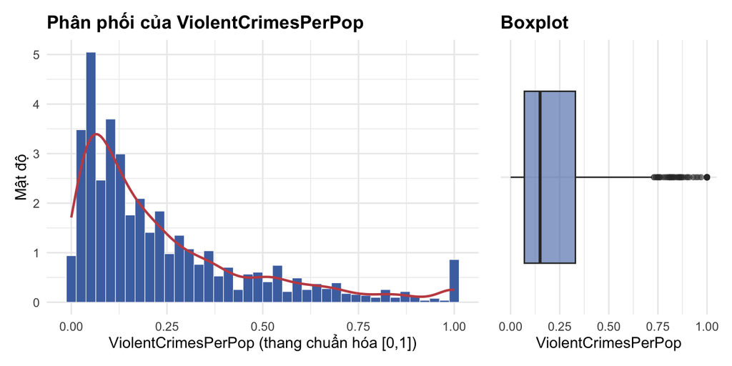

```r
p_hist <- ggplot(data.frame(y), aes(y)) +
  geom_histogram(aes(y = after_stat(density)), bins = 40,
                 fill = "#4C72B0", color = "white", linewidth = 0.2) +
  geom_density(color = "#C44E52", linewidth = 0.9) +
  labs(title = "Phân phối của ViolentCrimesPerPop",
       x = "ViolentCrimesPerPop (thang chuẩn hóa [0,1])", y = "Mật độ")

p_box <- ggplot(data.frame(y), aes(x = y, y = "")) +
  geom_boxplot(fill = "#4C72B0", alpha = 0.6, outlier.alpha = 0.3) +
  labs(title = "Boxplot", x = "ViolentCrimesPerPop", y = NULL)

p_hist + p_box + plot_layout(widths = c(2, 1))
```

**Nhận xét.** Phân phối của biến phản hồi **lệch phải rõ rệt**: skewness $g_1 = 1.52 > 0$, trung bình (0.238) lớn hơn hẳn trung vị (0.15). Phần lớn cộng đồng có tỷ lệ tội phạm bạo lực thấp (50% số cộng đồng dưới 0.15), trong khi một đuôi dài các cộng đồng có tỷ lệ rất cao. Đáng chú ý có 44 quan sát (2.2%) nằm đúng tại $y = 1$: đây là hệ quả của phép chuẩn hóa min–max có cắt tại $\pm 3$ độ lệch chuẩn của tác giả bộ dữ liệu — các cộng đồng nguy hiểm nhất bị **dồn (censored) về cùng một giá trị trần**. Hai hệ quả cần ghi nhớ: (i) mô hình tuyến tính sẽ khó phân biệt các cộng đồng trong nhóm trần này, tạo một giới hạn trên tự nhiên cho $R^2$; (ii) đuôi phải dài không phải là “lỗi dữ liệu” mà là đặc điểm thực của hiện tượng tội phạm — điểm này sẽ được dùng khi bàn về giá trị ngoại lai ở cuối mục.

## 3.2 Cấu trúc dữ liệu khuyết

Ta thống kê số giá trị khuyết theo từng biến và khảo sát xem chúng có cấu trúc gì đặc biệt hay không — vì cách xử lý đúng phụ thuộc vào **cơ chế sinh dữ liệu khuyết** (Little & Rubin: MCAR / MAR / MNAR), chứ không chỉ tỷ lệ khuyết.

```r
miss <- colSums(is.na(crime))
miss_tab <- tibble::tibble(
  `Biến` = names(miss), `Số NA` = miss,
  `Tỷ lệ (%)` = round(100 * miss / nrow(crime), 1)
) |>
  filter(`Số NA` > 0) |>
  arrange(desc(`Số NA`))

kb(head(miss_tab, 10), caption = "10 biến khuyết nhiều nhất (tổng cộng 25 biến có khuyết).")
```

10 biến khuyết nhiều nhất (tổng cộng 25 biến có khuyết).

| Biến | Số NA | Tỷ lệ (%) |
| --- | --- | --- |
| LemasSwornFT | 1675 | 84 |
| LemasSwFTPerPop | 1675 | 84 |
| LemasSwFTFieldOps | 1675 | 84 |
| LemasSwFTFieldPerPop | 1675 | 84 |
| LemasTotalReq | 1675 | 84 |
| LemasTotReqPerPop | 1675 | 84 |
| PolicReqPerOffic | 1675 | 84 |
| PolicPerPop | 1675 | 84 |
| RacialMatchCommPol | 1675 | 84 |
| PctPolicWhite | 1675 | 84 |

```r
# Nhóm biến khuyết "theo khối": các biến police/LEMAS cùng khuyết 1675 dòng
heavy_miss <- miss_tab$`Biến`[miss_tab$`Tỷ lệ (%)` > 50 &
                              !(miss_tab$`Biến` %in% c("county", "community"))]
length(heavy_miss)
```

```
## [1] 22
```

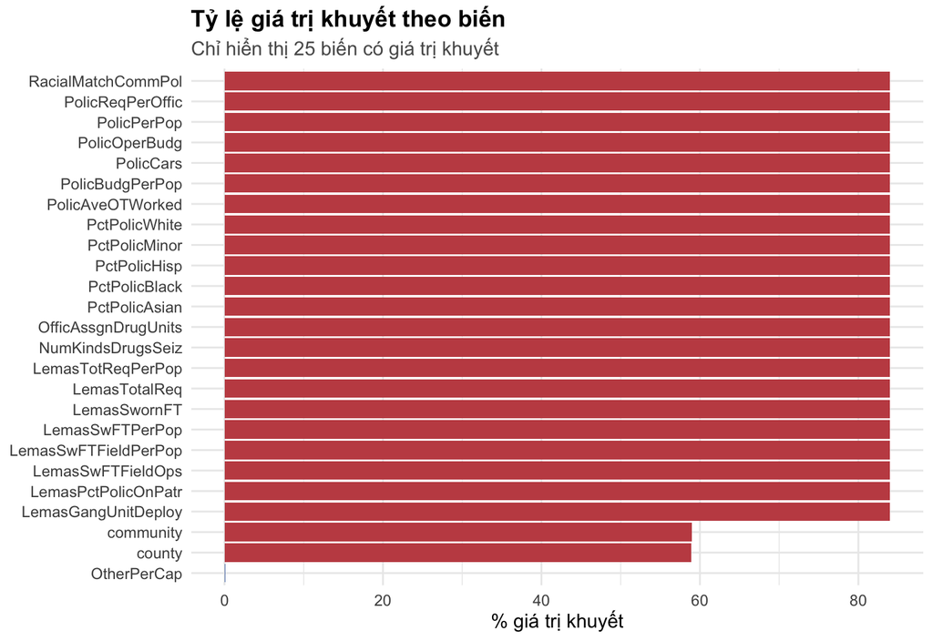

```r
ggplot(miss_tab, aes(x = reorder(`Biến`, `Tỷ lệ (%)`), y = `Tỷ lệ (%)`)) +
  geom_col(aes(fill = `Tỷ lệ (%)` > 50), show.legend = FALSE) +
  scale_fill_manual(values = c(`TRUE` = "#C44E52", `FALSE` = "#4C72B0")) +
  coord_flip() +
  labs(title = "Tỷ lệ giá trị khuyết theo biến",
       subtitle = "Chỉ hiển thị 25 biến có giá trị khuyết",
       x = NULL, y = "% giá trị khuyết")
```

Toàn bộ 22 biến khuyết nặng đều thuộc nhóm **cảnh sát (LEMAS)** và cùng khuyết **đúng 1 675 dòng như nhau** — tức dữ liệu khuyết **theo khối quan sát** chứ không rải rác ngẫu nhiên: một cộng đồng hoặc có đầy đủ cả khối biến LEMAS, hoặc không có biến nào. Để tìm nguyên nhân, ta so sánh quy mô dân số giữa hai nhóm:

```r
lemas_missing <- is.na(crime$LemasSwornFT)
tab_mnar <- crime |>
  mutate(`Nhóm` = ifelse(lemas_missing, "Khuyết khối LEMAS", "Có dữ liệu LEMAS")) |>
  group_by(`Nhóm`) |>
  summarise(
    `Số cộng đồng` = n(),
    `Trung vị population` = median(population),
    `Trung bình population` = mean(population)
  )
kb(tab_mnar, digits = 3,
   caption = "So sánh quy mô dân số (thang chuẩn hóa) giữa nhóm có / khuyết dữ liệu LEMAS.")
```

So sánh quy mô dân số (thang chuẩn hóa) giữa nhóm có / khuyết dữ liệu LEMAS.

| Nhóm | Số cộng đồng | Trung vị population | Trung bình population |
| --- | --- | --- | --- |
| Có dữ liệu LEMAS | 319 | 0.14 | 0.229 |
| Khuyết khối LEMAS | 1675 | 0.02 | 0.025 |

**Nhận xét.** Cơ chế khuyết ở đây **không phải ngẫu nhiên hoàn toàn (không MCAR)**: nhóm khuyết LEMAS có trung vị `population` chuẩn hóa chỉ 0.02, so với 0.14 ở nhóm có dữ liệu — khảo sát LEMAS 1990 chỉ thu thập đầy đủ với các sở cảnh sát lớn, nên các cộng đồng nhỏ gần như không có dữ liệu. Việc khuyết phụ thuộc quy mô cộng đồng như vậy khiến mọi phép **imputation trở nên không đáng tin cậy**: ta sẽ phải ngoại suy giá trị cho 84% quan sát (đa số là cộng đồng nhỏ) từ mô hình học trên 16% quan sát còn lại vốn thiên lệch hẳn về các đô thị lớn. Quyết định xử lý cụ thể được trình bày ở Mục 4. Ngoài khối LEMAS, chỉ còn `OtherPerCap` khuyết đúng **1** giá trị; hai biến `county`, `community` khuyết ~59% nhưng là biến định danh, không tham gia mô hình.

## 3.3 Tương quan giữa các biến và với biến phản hồi

Từ đây, để khảo sát cấu trúc tương quan, ta làm việc trên tập biến dự báo sẽ được chốt chính thức ở Mục 4 (bỏ 5 biến non-predictive và khối LEMAS khuyết 84%; giá trị khuyết duy nhất của `OtherPerCap` được thay tạm bằng trung vị): ma trận $\mathbf{X}$ gồm $100$ biến, $n = 1994$ quan sát.

```r
non_pred <- c("state", "county", "community", "communityname", "fold")
X_eda <- crime[, setdiff(names(crime), c(non_pred, heavy_miss, "ViolentCrimesPerPop"))]
X_eda$OtherPerCap[is.na(X_eda$OtherPerCap)] <- median(X_eda$OtherPerCap, na.rm = TRUE)
dim(X_eda)
```

```
## [1] 1994  100
```

```r
r_y <- cor(X_eda, y)[, 1]
tab_ry <- tibble::tibble(`Biến` = names(r_y), `Tương quan với y` = r_y) |>
  arrange(desc(abs(`Tương quan với y`))) |>
  head(15)
kb(tab_ry, digits = 3, caption = "15 biến tương quan mạnh nhất với ViolentCrimesPerPop.")
```

15 biến tương quan mạnh nhất với ViolentCrimesPerPop.

| Biến | Tương quan với y |
| --- | --- |
| PctKids2Par | -0.738 |
| PctIlleg | 0.738 |
| PctFam2Par | -0.707 |
| racePctWhite | -0.685 |
| PctYoungKids2Par | -0.666 |
| PctTeen2Par | -0.662 |
| racepctblack | 0.631 |
| pctWInvInc | -0.576 |
| pctWPubAsst | 0.575 |
| FemalePctDiv | 0.556 |
| TotalPctDiv | 0.553 |
| PctPersOwnOccup | -0.525 |
| MalePctDivorce | 0.525 |
| PctPopUnderPov | 0.522 |
| PctUnemployed | 0.504 |

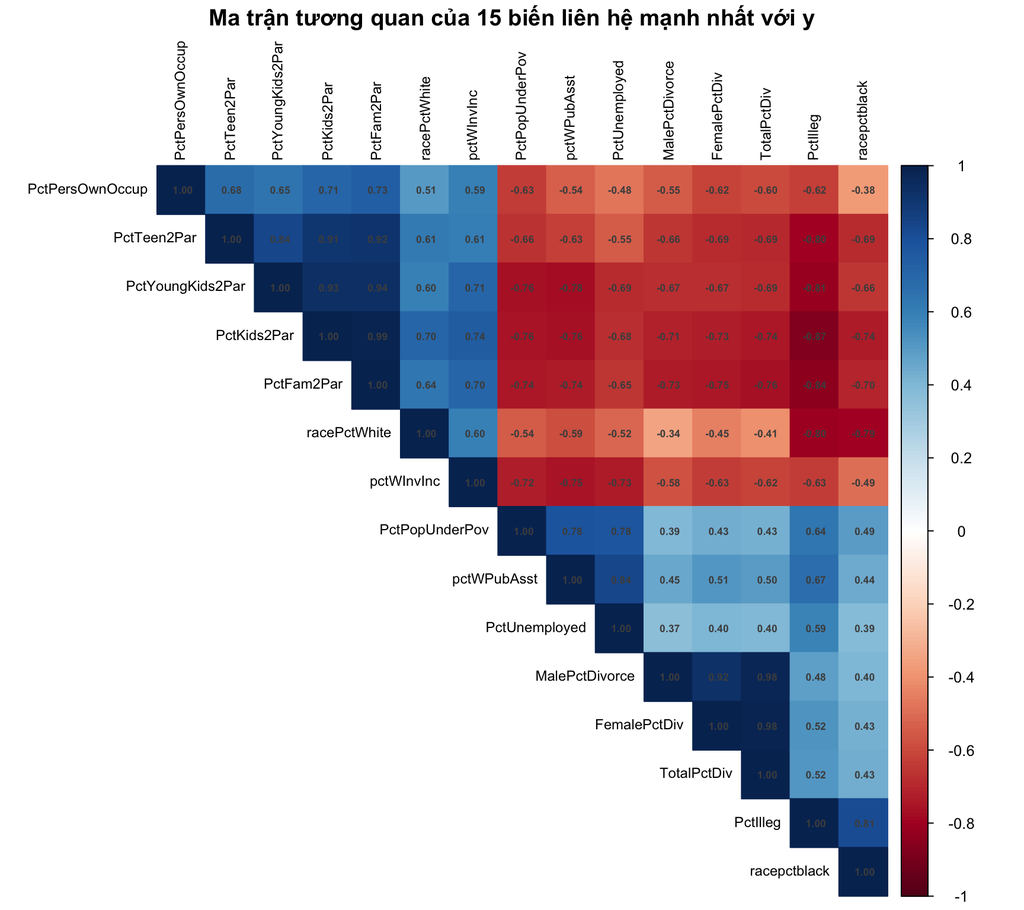

```r
vars_top <- tab_ry$`Biến`
corrplot::corrplot(
  cor(X_eda[, vars_top]),
  method = "color", type = "upper", order = "hclust",
  tl.col = "black", tl.cex = 0.75, addCoef.col = "grey30", number.cex = 0.55,
  mar = c(0, 0, 1.5, 0),
  title = "Ma trận tương quan của 15 biến liên hệ mạnh nhất với y"
)
```

```r
R <- cor(X_eda)
r_upper <- R[upper.tri(R)]
tab_pairs <- tibble::tibble(
  `Ngưỡng` = c("|r| > 0.8", "|r| > 0.9"),
  `Số cặp biến` = c(sum(abs(r_upper) > 0.8), sum(abs(r_upper) > 0.9)),
  `Trên tổng số cặp` = sprintf("%d", length(r_upper))
)
kb(tab_pairs, caption = "Số cặp biến dự báo có tương quan tuyệt đối vượt ngưỡng.")
```

Số cặp biến dự báo có tương quan tuyệt đối vượt ngưỡng.

| Ngưỡng | Số cặp biến | Trên tổng số cặp |
| --- | --- | --- |
| &#124;r&#124; > 0.8 | 127 | 4950 |
| &#124;r&#124; > 0.9 | 49 | 4950 |

**Nhận xét.** Hai điều nổi bật từ kết quả trên:

- **Về liên hệ với biến phản hồi:** các biến tương quan mạnh nhất với tỷ lệ tội phạm đều thuộc nhóm **cấu trúc gia đình** — `PctKids2Par` ($r = -0.738$), `PctIlleg` ($r = 0.738$), `PctFam2Par` ($r = -0.707$) — cùng các biến cơ cấu chủng tộc và nghèo đói (`racePctWhite`, `pctWPubAsst`, `PctPopUnderPov`). Dấu của các tương quan nhất quán với trực giác xã hội học: cộng đồng có tỷ lệ trẻ em sống cùng hai bố mẹ cao thì tỷ lệ tội phạm thấp, và ngược lại với tỷ lệ nghèo/trợ cấp.
- **Về tương quan giữa các biến dự báo:** có tới 127 cặp biến với $|r| > 0.8$ và 49 cặp với $|r| > 0.9$ (tối đa $|r| = 0.996$). Ngay trong hình trên cũng thấy các khối biến gần như trùng thông tin (`PctFam2Par`–`PctKids2Par`–`PctYoungKids2Par`–`PctTeen2Par`; `TotalPctDiv`–`FemalePctDiv`–`MalePctDivorce`). Đây là biểu hiện trực tiếp của **đa cộng tuyến**, được định lượng chặt chẽ hơn ngay dưới đây.

## 3.4 Chẩn đoán đa cộng tuyến định lượng

Mức độ đa cộng tuyến được đo bằng hai công cụ chuẩn:

```r
ev <- eigen(R, symmetric = TRUE, only.values = TRUE)$values
cond_index <- sqrt(max(ev) / min(ev))

fit_vif <- lm(y ~ ., data = data.frame(y = y, X_eda))
vif_all <- car::vif(fit_vif)

tab_mc <- tibble::tibble(
  `Chỉ tiêu` = c("$\\lambda_{\\max}$", "$\\lambda_{\\min}$",
                 "Chỉ số điều kiện $\\kappa = \\sqrt{\\lambda_{\\max}/\\lambda_{\\min}}$",
                 "Số biến có VIF > 10", "Số biến có VIF > 100", "VIF lớn nhất"),
  `Giá trị` = c(round(max(ev), 2), signif(min(ev), 2), round(cond_index, 1),
                sprintf("%d / %d", sum(vif_all > 10), length(vif_all)),
                sum(vif_all > 100), round(max(vif_all))),
  `Ngưỡng tham chiếu` = c("—", "—", "> 30: nghiêm trọng (Belsley)",
                          "VIF > 10: đáng lo ngại", "—", "—")
)
kb(tab_mc, caption = "Chẩn đoán đa cộng tuyến trên ma trận 100 biến dự báo.")
```

Chẩn đoán đa cộng tuyến trên ma trận 100 biến dự báo.

| Chỉ tiêu | Giá trị | Ngưỡng tham chiếu |
| --- | --- | --- |
| $\lambda_{\max}$ | 25.18 | — |
| $\lambda_{\min}$ | 0.00063 | — |
| Chỉ số điều kiện $\kappa = \sqrt{\lambda_{\max}/\lambda_{\min}}$ | 199.9 | > 30: nghiêm trọng (Belsley) |
| Số biến có VIF > 10 | 65 / 100 | VIF > 10: đáng lo ngại |
| Số biến có VIF > 100 | 22 | — |
| VIF lớn nhất | 1037 | — |

```r
kb(tibble::tibble(`Biến` = names(sort(vif_all, decreasing = TRUE)[1:5]),
                  `VIF` = round(sort(vif_all, decreasing = TRUE)[1:5])),
   caption = "5 biến có VIF cao nhất.")
```

5 biến có VIF cao nhất.

| Biến | VIF |
| --- | --- |
| TotalPctDiv | 1037 |
| OwnOccMedVal | 578 |
| PctPersOwnOccup | 570 |
| PctHousOwnOcc | 551 |
| PctRecImmig8 | 478 |

**Nhận xét.** Mọi chỉ tiêu đều vượt ngưỡng cảnh báo **rất xa**: chỉ số điều kiện $\kappa \approx 200$ — gấp gần 7 lần ngưỡng “nghiêm trọng” 30 của Belsley; 65/100 biến có VIF > 10, trong đó 22 biến có VIF > 100, cực đại là `TotalPctDiv` với VIF $\approx 1037$ (nghĩa là phương sai ước lượng hệ số của biến này bị phóng đại hơn nghìn lần so với trường hợp trực giao). Kết luận: **OLS trên toàn bộ biến sẽ cho các hệ số cực kỳ bất ổn định** (phương sai lớn, dấu có thể đảo ngược tùy mẫu), dù khả năng dự đoán tổng thể có thể vẫn chấp nhận được. Đây chính là bối cảnh mà các phương pháp **PCR, Ridge và LASSO** được thiết kế để giải quyết — bằng cách giảm chiều (PCR) hoặc regularization (Ridge/LASSO), đánh đổi một lượng chệch (bias) nhỏ lấy mức giảm phương sai lớn.

## 3.5 Giá trị ngoại lai

Cuối cùng, ta khảo sát giá trị ngoại lai bằng **quy tắc hàng rào IQR** của Tukey: giá trị bị gắn cờ nếu nằm ngoài $[Q_1 - 1.5\,\mathrm{IQR},\; Q_3 + 1.5\,\mathrm{IQR}]$. Ta chọn quy tắc này để *khảo sát* vì nó **không đặt giả định phân phối** (distribution-free): hàng rào chỉ dựa trên các tứ phân vị, vẫn có ý nghĩa với phân phối lệch, khác với quy tắc $\bar{x} \pm 3s$ vốn chỉ hợp lý dưới giả định gần chuẩn — điều mà kết quả EDA ở trên cho thấy dữ liệu này không thỏa.

```r
iqr_flag <- function(x) {
  q <- quantile(x, c(0.25, 0.75))
  fence <- 1.5 * diff(q)
  x < q[1] - fence | x > q[2] + fence
}
flags <- sapply(X_eda, iqr_flag)

tab_flag <- tibble::tibble(
  `Chỉ tiêu` = c("Tỷ lệ ô giá trị bị gắn cờ (toàn bảng)",
                 "Số quan sát có ít nhất 1 biến bị gắn cờ",
                 "Số quan sát bị gắn cờ ở từ 10 biến trở lên"),
  `Giá trị` = c(sprintf("%.2f %%", 100 * mean(flags)),
                sprintf("%d / %d (%.1f %%)", sum(rowSums(flags) > 0),
                        nrow(X_eda), 100 * mean(rowSums(flags) > 0)),
                sum(rowSums(flags) >= 10))
)
kb(tab_flag, caption = "Kết quả gắn cờ ngoại lai theo quy tắc IQR trên 100 biến dự báo.")
```

Kết quả gắn cờ ngoại lai theo quy tắc IQR trên 100 biến dự báo.

| Chỉ tiêu | Giá trị |
| --- | --- |
| Tỷ lệ ô giá trị bị gắn cờ (toàn bảng) | 4.74 % |
| Số quan sát có ít nhất 1 biến bị gắn cờ | 1538 / 1994 (77.1 %) |
| Số quan sát bị gắn cờ ở từ 10 biến trở lên | 373 |

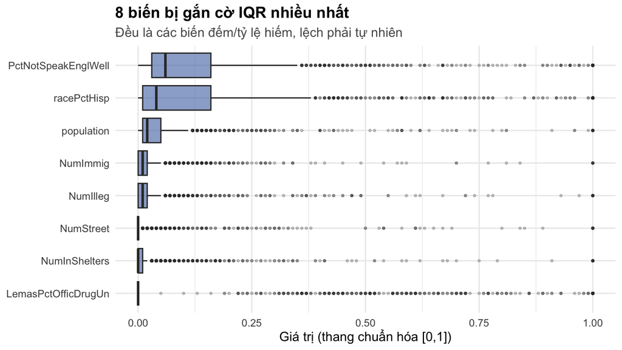

```r
top_flag <- sort(colSums(flags), decreasing = TRUE)[1:8]
X_eda |>
  select(all_of(names(top_flag))) |>
  pivot_longer(everything(), names_to = "Bien", values_to = "gia_tri") |>
  ggplot(aes(x = reorder(Bien, gia_tri, FUN = median), y = gia_tri)) +
  geom_boxplot(fill = "#4C72B0", alpha = 0.6, outlier.alpha = 0.25, outlier.size = 0.8) +
  coord_flip() +
  labs(title = "8 biến bị gắn cờ IQR nhiều nhất",
       subtitle = "Đều là các biến đếm/tỷ lệ hiếm, lệch phải tự nhiên",
       x = NULL, y = "Giá trị (thang chuẩn hóa [0,1])")
```

**Nhận xét và quyết định.** Nếu loại mọi quan sát có ít nhất một giá trị bị gắn cờ, ta sẽ mất 77.1% dữ liệu — điều này tự nó cho thấy “ngoại lai” ở đây không phải lỗi đo lường mà là **đặc điểm cấu trúc của dữ liệu**. Ta quyết định **không loại quan sát nào**, với ba lý do:

1. Các biến bị gắn cờ nhiều nhất (`NumStreet`, `NumInShelters`, `NumIlleg`, `NumImmig`…) đều là **biến đếm các hiện tượng hiếm**, phân phối lệch phải tự nhiên; giá trị lớn của chúng là thông tin thực (các thành phố lớn), không phải nhiễu.
2. Dữ liệu đã được tác giả **cắt sẵn tại $\pm 3$ SD** trong bước chuẩn hóa min–max — các ngoại lai cực đoan nhất đã bị xử lý từ nguồn.
3. Các cộng đồng có tỷ lệ tội phạm cực cao chính là **đối tượng cần dự đoán**; loại chúng theo tiêu chí thống kê là tự cắt bỏ một phần miền giá trị của $y$ (truncation có hệ thống), làm chệch mô hình và giảm giá trị thực tiễn.

Thay vì xóa trước, ta sẽ kiểm soát rủi ro bằng **chẩn đoán ảnh hưởng** (đòn bẩy và khoảng cách Cook) trên mô hình OLS ở Mục 7 — nếu một vài quan sát chi phối quá mức kết quả ước lượng, khi đó mới cân nhắc phân tích độ nhạy.

# 4 Tiền xử lý dữ liệu

Từ các phát hiện của EDA, ta chốt các quyết định tiền xử lý sau. Nguyên tắc chung: **mỗi thao tác phải có lý do thống kê tường minh**, và mọi tham số ước lượng từ dữ liệu (trung vị để điền khuyết, trung bình/độ lệch chuẩn để chuẩn hóa) sẽ chỉ được **học trên tập huấn luyện** — chi tiết ở Mục 5.

[output not shown]

```r
X0 <- crime[, setdiff(names(crime), c(non_pred, heavy_miss, "ViolentCrimesPerPop"))]

# Kiểm tra phương sai gần 0
sd_all <- sapply(X0, sd, na.rm = TRUE)
tab_nzv <- tibble::tibble(
  `Chỉ tiêu` = c("Độ lệch chuẩn nhỏ nhất", "Biến tương ứng",
                 "Số biến có sd < 0.01", "Số giá trị duy nhất ít nhất"),
  `Kết quả` = c(round(min(sd_all), 3), names(which.min(sd_all)),
                sum(sd_all < 0.01),
                sprintf("%d (biến MedNumBR)", min(sapply(X0, function(x) length(unique(x))))))
)
kb(tab_nzv, caption = "Kiểm tra biến phương sai gần 0.")
```

Kiểm tra biến phương sai gần 0.

| Chỉ tiêu | Kết quả |
| --- | --- |
| Độ lệch chuẩn nhỏ nhất | 0.087 |
| Biến tương ứng | NumImmig |
| Số biến có sd < 0.01 | 0 |
| Số giá trị duy nhất ít nhất | 3 (biến MedNumBR) |

```r
dim(X0)
```

```
## [1] 1994  100
```

**Nhận xét.** Không có biến nào phương sai gần 0 (độ lệch chuẩn nhỏ nhất 0.087 thuộc về `NumImmig` — vẫn đủ lớn), nên không cần loại thêm biến nào ở bước này. Biến `MedNumBR` chỉ nhận 3 giá trị phân biệt (do là trung vị số phòng ngủ đã chuẩn hóa) nhưng vẫn có phương sai đáng kể nên được giữ lại. Sau tiền xử lý, ma trận biến dự báo gồm $n = 1994$ quan sát và $p = 100$ biến; biến khuyết duy nhất còn lại (`OtherPerCap`, 1 giá trị) sẽ được điền **sau khi chia dữ liệu** để tuân thủ nguyên tắc chống rò rỉ thông tin.

# 5 Chia dữ liệu

## 5.1 Nguyên tắc chống rò rỉ thông tin (data leakage)

Tập kiểm định (*validation set*) có nhiệm vụ mô phỏng dữ liệu **chưa từng thấy**. Vì vậy, mọi đại lượng ước lượng từ dữ liệu trong quá trình tiền xử lý và huấn luyện — trung vị điền khuyết, trung bình $\bar{x}_j$ và độ lệch chuẩn $s_j$ dùng để chuẩn hóa, các vector tải của PCA, tham số $\lambda$ của Ridge/LASSO — đều chỉ được **ước lượng trên tập huấn luyện**, sau đó **áp nguyên** sang tập kiểm định. Nếu vi phạm (ví dụ chuẩn hóa trên toàn bộ dữ liệu trước khi chia), thông tin của tập kiểm định sẽ “rò” vào mô hình, khiến các chỉ số đánh giá lạc quan hơn thực tế một cách hệ thống.

## 5.2 Thực hiện chia và kiểm tra tính cân bằng

Ta chia ngẫu nhiên **80% huấn luyện / 20% kiểm định** với hạt giống cố định để tái lập được kết quả. Tỷ lệ 80/20 cho tập kiểm định khoảng 400 quan sát — đủ lớn để ước lượng RMSE/MAE ổn định, trong khi vẫn giữ tối đa dữ liệu cho việc ước lượng PCA và các mô hình nhiều tham số. Sau khi chia, ta kiểm tra hai tập có phân phối biến phản hồi tương đồng hay không bằng so sánh phân vị và **kiểm định Kolmogorov–Smirnov hai mẫu** (thống kê $D = \sup_t |\hat F_{train}(t) - \hat F_{val}(t)|$ — cũng là một kiểm định phi tham số, không giả định dạng phân phối).

```r
set.seed(SEED)
n <- nrow(X0)
idx_train <- sample(seq_len(n), size = round(0.8 * n))

X_train <- X0[idx_train, ]; X_val <- X0[-idx_train, ]
y_train <- y[idx_train];    y_val  <- y[-idx_train]

# Điền khuyết OtherPerCap bằng trung vị HỌC TRÊN TRAIN
med_opc <- median(X_train$OtherPerCap, na.rm = TRUE)
X_train$OtherPerCap[is.na(X_train$OtherPerCap)] <- med_opc
X_val$OtherPerCap[is.na(X_val$OtherPerCap)]     <- med_opc

c(n_train = nrow(X_train), n_val = nrow(X_val))
```

```
## n_train   n_val
##    1595     399
```

```r
ks <- suppressWarnings(ks.test(y_train, y_val))

tab_split <- tibble::tibble(
  `Tập` = c("Huấn luyện", "Kiểm định"),
  `n` = c(length(y_train), length(y_val)),
  `Trung bình y` = c(mean(y_train), mean(y_val)),
  `Trung vị y` = c(median(y_train), median(y_val)),
  `Độ lệch chuẩn y` = c(sd(y_train), sd(y_val))
)
kb(tab_split, digits = 3, caption = "So sánh phân phối biến phản hồi giữa hai tập.")
```

So sánh phân phối biến phản hồi giữa hai tập.

| Tập | n | Trung bình y | Trung vị y | Độ lệch chuẩn y |
| --- | --- | --- | --- | --- |
| Huấn luyện | 1595 | 0.234 | 0.15 | 0.230 |
| Kiểm định | 399 | 0.252 | 0.17 | 0.244 |

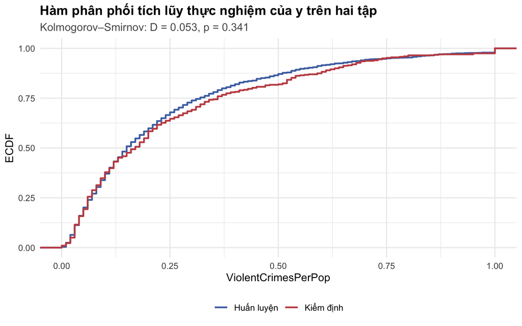

```r
ggplot(data.frame(y = c(y_train, y_val),
                  tap = rep(c("Huấn luyện", "Kiểm định"),
                            c(length(y_train), length(y_val)))),
       aes(y, color = tap)) +
  stat_ecdf(linewidth = 0.9) +
  scale_color_manual(values = c("Huấn luyện" = "#4C72B0", "Kiểm định" = "#C44E52")) +
  labs(title = "Hàm phân phối tích lũy thực nghiệm của y trên hai tập",
       subtitle = sprintf("Kolmogorov–Smirnov: D = %.3f, p = %.3f", ks$statistic, ks$p.value),
       x = "ViolentCrimesPerPop", y = "ECDF", color = NULL)
```

**Nhận xét.** Phép chia cho $n_{train} = 1595$, $n_{val} = 399$. Hai tập có phân phối biến phản hồi tương đồng: trung bình 0.234 so với 0.252, hai đường ECDF gần trùng khít, và kiểm định KS không bác bỏ giả thuyết hai mẫu cùng phân phối ($D = 0.053$, $p = 0.341 > 0.05$). Như vậy không cần chia phân tầng (stratified split); phép chia ngẫu nhiên đơn giản đã đủ cân bằng. Giá trị khuyết duy nhất của `OtherPerCap` rơi vào tập huấn luyện và được điền bằng trung vị tập huấn luyện ($0.26$).

# 6 Mô hình hồi quy trên thành phần chính (PCR)

## 6.1 Cơ sở toán học

Gọi $\mathbf{X}_s$ là ma trận dự báo $n \times p$ **đã chuẩn hóa** (mỗi cột trừ trung bình, chia độ lệch chuẩn của tập huấn luyện). Phân tích thành phần chính xuất phát từ phân rã phổ của ma trận tương quan mẫu:

$$\mathbf{R} = \frac{1}{n-1}\mathbf{X}_s^\top \mathbf{X}_s =
\mathbf{V}\boldsymbol{\Lambda}\mathbf{V}^\top,
\qquad \boldsymbol{\Lambda} = \mathrm{diag}(\lambda_1 \ge \lambda_2 \ge
\dots \ge \lambda_p \ge 0),$$

trong đó các cột của $\mathbf{V}$ (vector riêng trực chuẩn, $\mathbf{V}^\top\mathbf{V} = \mathbf{I}$) là các **vector tải (loadings)**. Thành phần chính thứ $j$ là tổ hợp tuyến tính $\mathbf{z}_j = \mathbf{X}_s \mathbf{v}_j$; đây là hướng có phương sai mẫu cực đại ($\mathrm{Var}(\mathbf{z}_j) = \lambda_j$) trong số các hướng trực giao với $j-1$ hướng trước đó. **PCR giữ lại $k$ thành phần đầu** và hồi quy OLS của $y$ trên $\mathbf{Z}_k = \mathbf{X}_s\mathbf{V}_k$:

$$\hat{\boldsymbol{\gamma}} =
(\mathbf{Z}_k^\top\mathbf{Z}_k)^{-1}\mathbf{Z}_k^\top \mathbf{y},
\qquad
\hat{\boldsymbol{\beta}}^{PCR} =
\mathbf{V}_k\,\hat{\boldsymbol{\gamma}}.$$

Hai điểm làm nên giá trị của PCR trong bối cảnh đa cộng tuyến: (i) các cột của $\mathbf{Z}_k$ **trực giao** nên $\mathbf{Z}_k^\top\mathbf{Z}_k = (n-1)\,\mathrm{diag}(\lambda_1,\dots,\lambda_k)$ — bài toán nghịch đảo ma trận trở nên hoàn toàn ổn định; (ii) việc loại bỏ các hướng có $\lambda_j \approx 0$ — chính là các hướng làm phương sai của OLS bùng nổ (Mục 3.4) — tương đương chấp nhận một lượng chệch nhỏ để đổi lấy mức giảm phương sai lớn.

Hai lựa chọn phương pháp cần biện minh:

- **PCA trên ma trận tương quan** (chuẩn hóa biến) thay vì ma trận hiệp phương sai: tuy các biến cùng nằm trên thang $[0,1]$, phép min–max của tác giả không đồng nhất **phương sai** giữa các biến (biến có phân phối tập trung sẽ có phương sai nhỏ hơn nhiều). PCA trên hiệp phương sai sẽ ưu tiên các biến có phương sai lớn một cách tùy tiện theo thang đo; chuẩn hóa đưa mọi biến về vai trò đối xứng.
- **Tham số chuẩn hóa** ($\bar x_j, s_j$) ước lượng trên tập huấn luyện và áp nguyên sang tập kiểm định (Mục 5.1).

## 6.2 Kiểm tra mức độ phù hợp của dữ liệu với PCR

PCR chỉ có ý nghĩa khi các biến thực sự chia sẻ cấu trúc tương quan chung — nếu các biến gần như trực giao thì không thể “nén” thông tin vào ít thành phần. Ta dùng hai kiểm định/chỉ số chuẩn của phân tích thành phần:

- **Kiểm định Bartlett về tính cầu (sphericity)**: $H_0: \mathbf{R} = \mathbf{I}$ (các biến không tương quan). Thống kê $\chi^2 = -\left(n - 1 - \frac{2p+5}{6}\right)\ln|\mathbf{R}|$ với $p(p-1)/2$ bậc tự do. Bác bỏ $H_0$ là điều kiện cần để PCA có ý nghĩa.
- **Chỉ số Kaiser–Meyer–Olkin (KMO / MSA)**: so sánh tương quan thường $r_{ij}$ với tương quan riêng phần $q_{ij}$ (sau khi loại ảnh hưởng các biến khác): $\mathrm{KMO} = \frac{\sum\sum r_{ij}^2}{\sum\sum r_{ij}^2 + \sum\sum q_{ij}^2}$. KMO gần 1 nghĩa là tương quan giữa các biến chủ yếu là **tương quan chung** (được chia sẻ qua các nhân tố tiềm ẩn) — chính là cấu trúc mà PCA khai thác. Thang đánh giá của Kaiser: $\ge 0.9$ tuyệt vời, $0.8$–$0.9$ tốt, dưới $0.5$ không chấp nhận được.

```r
R_train <- cor(X_train)
bart <- psych::cortest.bartlett(R_train, n = nrow(X_train))
kmo  <- psych::KMO(R_train)

tab_suit <- tibble::tibble(
  `Chỉ tiêu` = c("Bartlett $\\chi^2$", "Bậc tự do", "p-value",
                 "KMO tổng thể", "KMO nhỏ nhất theo biến", "Số biến có $MSA_i < 0.5$"),
  `Giá trị` = c(format(round(bart$chisq), big.mark = " "), bart$df,
                format.pval(bart$p.value, eps = 1e-300),
                round(kmo$MSA, 3),
                sprintf("%.3f (%s)", min(kmo$MSAi), names(which.min(kmo$MSAi))),
                sum(kmo$MSAi < 0.5)),
  `Diễn giải` = c("Rất lớn so với df", "$p(p-1)/2 = 4950$", "Bác bỏ $H_0: R = I$",
                  "Mức “tuyệt vời” ($\\ge 0.9$)", "Vẫn trên mức chấp nhận 0.5", "—")
)
kb(tab_suit, caption = "Kiểm tra mức độ phù hợp của dữ liệu với PCA/PCR (trên tập huấn luyện).")
```

Kiểm tra mức độ phù hợp của dữ liệu với PCA/PCR (trên tập huấn luyện).

| Chỉ tiêu | Giá trị | Diễn giải |
| --- | --- | --- |
| Bartlett $\chi^2$ | 342 736 | Rất lớn so với df |
| Bậc tự do | 4950 | $p(p-1)/2 = 4950$ |
| p-value | < 1e-300 | Bác bỏ $H_0: R = I$ |
| KMO tổng thể | 0.924 | Mức “tuyệt vời” ($\ge 0.9$) |
| KMO nhỏ nhất theo biến | 0.761 (PctEmplManu) | Vẫn trên mức chấp nhận 0.5 |
| Số biến có $MSA_i &lt; 0.5$ | 0 | — |

**Nhận xét.** Cả hai tiêu chí đều khẳng định dữ liệu **rất phù hợp** với PCR: kiểm định Bartlett bác bỏ dứt khoát giả thuyết ma trận tương quan đơn vị ($\chi^2 \approx 342 736$ với $4950$ bậc tự do, $p < 10^{-300}$), và KMO tổng thể đạt $0.924$ — mức “tuyệt vời” theo thang Kaiser; không biến nào có MSA riêng dưới 0.5 (thấp nhất là PctEmplManu với $0.761$). Kết hợp với chỉ số điều kiện $\kappa \approx 200$ ở Mục 3.4, ta có bức tranh nhất quán: các biến chia sẻ rất nhiều phương sai chung — đúng loại cấu trúc mà PCA nén hiệu quả.

## 6.3 Phân tích thành phần chính trên tập huấn luyện

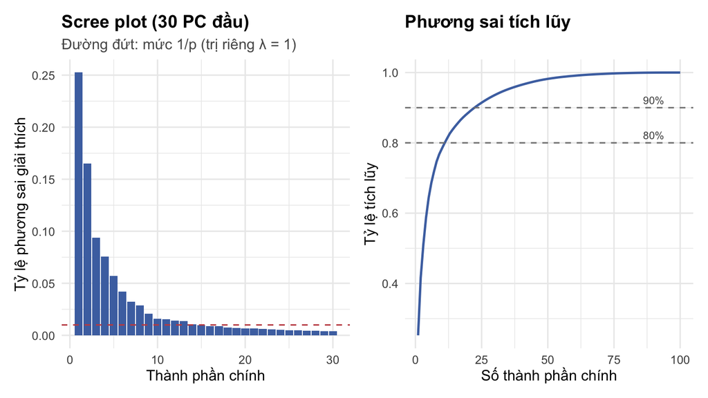

```r
pca_train <- prcomp(X_train, center = TRUE, scale. = TRUE)
lambda <- pca_train$sdev^2
pve <- lambda / sum(lambda)

df_scree <- tibble::tibble(PC = seq_along(pve), pve = pve, cum = cumsum(pve))

p_scree <- ggplot(df_scree[1:30, ], aes(PC, pve)) +
  geom_col(fill = "#4C72B0") +
  geom_hline(yintercept = 1 / length(pve), linetype = 2, color = "#C44E52") +
  labs(title = "Scree plot (30 PC đầu)",
       subtitle = "Đường đứt: mức 1/p (trị riêng λ = 1)",
       x = "Thành phần chính", y = "Tỷ lệ phương sai giải thích")

p_cum <- ggplot(df_scree, aes(PC, cum)) +
  geom_line(color = "#4C72B0", linewidth = 0.9) +
  geom_hline(yintercept = c(0.8, 0.9), linetype = 2, color = "grey50") +
  annotate("text", x = 90, y = c(0.8, 0.9), label = c("80%", "90%"),
           vjust = -0.5, size = 3, color = "grey30") +
  labs(title = "Phương sai tích lũy", x = "Số thành phần chính", y = "Tỷ lệ tích lũy")

p_scree + p_cum
```

```r
tab_pve <- tibble::tibble(
  `Tiêu chí` = c("Kaiser: số PC có $\\lambda_j > 1$",
                 "Số PC đạt 80% phương sai tích lũy",
                 "Số PC đạt 90% phương sai tích lũy",
                 "PVE của PC1", "PVE của PC2"),
  `Kết quả` = c(sum(lambda > 1),
                which(cumsum(pve) >= 0.8)[1],
                which(cumsum(pve) >= 0.9)[1],
                sprintf("%.1f %%", 100 * pve[1]),
                sprintf("%.1f %%", 100 * pve[2]))
)
kb(tab_pve, caption = "Các tiêu chí mô tả về số thành phần chính.")
```

Các tiêu chí mô tả về số thành phần chính.

| Tiêu chí | Kết quả |
| --- | --- |
| Kaiser: số PC có $\lambda_j &gt; 1$ | 14 |
| Số PC đạt 80% phương sai tích lũy | 12 |
| Số PC đạt 90% phương sai tích lũy | 23 |
| PVE của PC1 | 25.2 % |
| PVE của PC2 | 16.5 % |

**Nhận xét.** Cấu trúc nén thông tin rất rõ: chỉ riêng PC1 đã giải thích 25.2% tổng phương sai của 100 biến, hai thành phần đầu giải thích 41.7%, và chỉ cần 12 thành phần để đạt 80% (so với 100 chiều gốc). Tiêu chí Kaiser ($\lambda_j > 1$: thành phần “mang nhiều thông tin hơn một biến gốc đơn lẻ”) giữ 14 thành phần. Tuy nhiên các tiêu chí này đều **chỉ nhìn vào $\mathbf{X}$** mà không nhìn vào $y$ — chúng đo lượng phương sai được giữ, không đo khả năng dự đoán. Quyết định cuối cùng vì vậy dựa trên kiểm chứng chéo dưới đây.

## 6.4 Lựa chọn số thành phần chính bằng kiểm chứng chéo

Ta chạy PCR với đủ 100 thành phần và **kiểm chứng chéo 10-fold trên tập huấn luyện** (tập kiểm định hoàn toàn không tham gia bước này), thu đường cong $\mathrm{RMSEP}(k)$. Số thành phần được chọn theo **quy tắc một sai số chuẩn (one-sigma)**: chọn $k$ **nhỏ nhất** sao cho $\mathrm{RMSEP}(k)$ không vượt quá $\min_k \mathrm{RMSEP} + 1\,\mathrm{SE}$ — vì các giá trị RMSEP quanh cực tiểu khác nhau ít hơn độ bất định của chính ước lượng CV, nên trong “vùng không phân biệt được” đó ta ưu tiên mô hình đơn giản nhất (nguyên tắc tiết kiệm). Ta đối chiếu thêm quy tắc kiểm định hoán vị (randomization test) của van der Voet (1994).

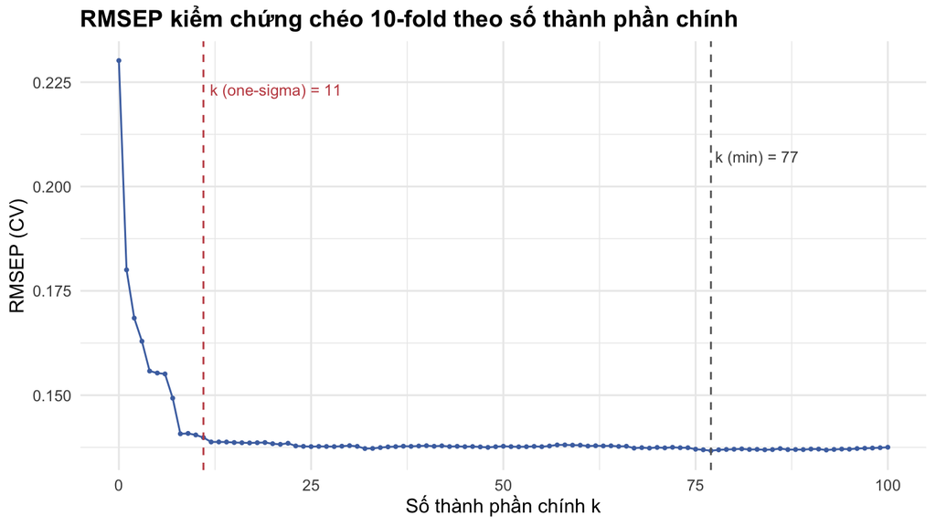

```r
library(pls)
set.seed(SEED)
df_train <- data.frame(y = y_train, X_train)

pcr_cv <- pcr(y ~ ., data = df_train, scale = TRUE, center = TRUE,
              validation = "CV", segments = 10)

rmsep_cv <- RMSEP(pcr_cv, estimate = "CV")$val[1, 1, ]
k_min  <- which.min(rmsep_cv) - 1          # trừ 1 vì phần tử đầu là mô hình 0 thành phần
k_1se  <- selectNcomp(pcr_cv, method = "onesigma", plot = FALSE)
k_rand <- selectNcomp(pcr_cv, method = "randomization", plot = FALSE)

df_rmsep <- tibble::tibble(k = 0:(length(rmsep_cv) - 1), RMSEP = as.numeric(rmsep_cv))
ggplot(df_rmsep, aes(k, RMSEP)) +
  geom_line(color = "#4C72B0") +
  geom_point(size = 0.7, color = "#4C72B0") +
  geom_vline(xintercept = c(k_1se, k_min), linetype = 2,
             color = c("#C44E52", "grey40")) +
  annotate("text", x = k_1se, y = max(df_rmsep$RMSEP) * 0.97,
           label = paste0("k (one-sigma) = ", k_1se), hjust = -0.05,
           color = "#C44E52", size = 3.4) +
  annotate("text", x = k_min, y = max(df_rmsep$RMSEP) * 0.90,
           label = paste0("k (min) = ", k_min), hjust = -0.05,
           color = "grey30", size = 3.4) +
  labs(title = "RMSEP kiểm chứng chéo 10-fold theo số thành phần chính",
       x = "Số thành phần chính k", y = "RMSEP (CV)")
```

```r
tab_k <- tibble::tibble(
  `Quy tắc` = c("Cực tiểu RMSEP", "One-sigma", "Randomization (van der Voet)"),
  `k` = c(k_min, k_1se, k_rand),
  `RMSEP (CV)` = round(c(min(rmsep_cv), rmsep_cv[k_1se + 1], rmsep_cv[k_rand + 1]), 4)
)
kb(tab_k, caption = "Số thành phần chính theo các quy tắc chọn trên CV.")
```

Số thành phần chính theo các quy tắc chọn trên CV.

| Quy tắc | k | RMSEP (CV) |
| --- | --- | --- |
| Cực tiểu RMSEP | 77 | 0.1367 |
| One-sigma | 11 | 0.1399 |
| Randomization (van der Voet) | 11 | 0.1399 |

**Nhận xét và quyết định.** Đường RMSEP giảm rất nhanh trong khoảng 10 thành phần đầu rồi gần như đi ngang: cực tiểu tuyệt đối nằm tại $k = 77$ với $\mathrm{RMSEP} = 0.1367$, nhưng mức cải thiện so với $k = 11$ ($\mathrm{RMSEP} = 0.1399$) chỉ là 0.0032 — nhỏ hơn nhiều so với sai số chuẩn của ước lượng CV, tức không có ý nghĩa thống kê. Cả quy tắc one-sigma lẫn kiểm định hoán vị đều thống nhất chọn $k = 11$; giá trị này cũng nằm cùng vùng với tiêu chí mô tả (Kaiser 14, mức 80% cần 12 thành phần). Ta **chọn $k = 11$ thành phần chính**, giữ lại 79.9% phương sai của $\mathbf{X}$ và giảm số tham số hồi quy từ 100 xuống 11.

```r
k_pcr <- k_1se
pcr_fit <- pcr(y ~ ., data = df_train, scale = TRUE, center = TRUE, ncomp = k_pcr)
pred_pcr_val <- as.numeric(predict(pcr_fit, newdata = X_val, ncomp = k_pcr))
```

Mô hình PCR cuối cùng được huấn luyện với $k = 11$ trên toàn bộ tập huấn luyện; dự đoán trên tập kiểm định sẽ được đánh giá cùng các mô hình đối chứng ở Mục 8.

# 7 Các mô hình đối chứng

## 7.1 Hồi quy bình phương tối thiểu (OLS)

Mô hình tuyến tính đầy đủ $y = \beta_0 + \mathbf{x}^\top\boldsymbol{\beta} + \varepsilon$ với ước lượng

$$\hat{\boldsymbol{\beta}}^{OLS} = \arg\min_{\boldsymbol\beta}\ \lVert
\mathbf{y} - \mathbf{X}\boldsymbol\beta \rVert_2^2 =
(\mathbf{X}^\top\mathbf{X})^{-1}\mathbf{X}^\top\mathbf{y}.$$

Theo định lý Gauss–Markov, OLS là ước lượng tuyến tính không chệch tốt nhất (BLUE) **nếu** các giả định thỏa mãn; nhưng “tốt nhất trong lớp không chệch” không có nghĩa là tốt nhất về sai số dự đoán khi $\mathbf{X}^\top\mathbf{X}$ gần suy biến — khi đó $\mathrm{Var}(\hat\beta_j) = \sigma^2 \cdot \mathrm{VIF}_j / \big[(n-1)s_j^2\big]$ bị phóng đại theo VIF.

```r
ols_fit <- lm(y ~ ., data = df_train)
sm_ols <- summary(ols_fit)

tab_ols <- tibble::tibble(
  `Chỉ tiêu` = c("$R^2$ (huấn luyện)", "$R^2$ hiệu chỉnh",
                 "Số hệ số có $|t| > 2$", "Tổng số hệ số"),
  `Giá trị` = c(round(sm_ols$r.squared, 3), round(sm_ols$adj.r.squared, 3),
                sum(abs(sm_ols$coefficients[, 3]) > 2), nrow(sm_ols$coefficients))
)
kb(tab_ols, caption = "Tóm tắt mô hình OLS đầy đủ trên tập huấn luyện.")
```

Tóm tắt mô hình OLS đầy đủ trên tập huấn luyện.

[output not shown]

**Nhận xét.** Mô hình giải thích được $R^2 = 0.694$ phương sai trên tập huấn luyện, nhưng chỉ 24/101 hệ số có $|t| > 2$. Nghịch lý “mô hình khớp tốt nhưng hầu hết hệ số không có ý nghĩa” là **triệu chứng kinh điển của đa cộng tuyến**: thông tin chung bị chia sẻ giữa các biến tương quan khiến từng hệ số riêng lẻ có sai số chuẩn khổng lồ, đúng như dự báo từ các VIF ở Mục 3.4.

### 7.1.1 Kiểm định các giả định của OLS

Ta kiểm tra bốn giả định: tuyến tính, phương sai sai số đồng nhất (kiểm định **Breusch–Pagan**: hồi quy $\hat\varepsilon_i^2$ trên các biến dự báo, $H_0$: phương sai đồng nhất), phân phối chuẩn của sai số (Q–Q plot và **Shapiro–Wilk**), và quan sát ảnh hưởng (**khoảng cách Cook** $D_i$, ngưỡng cảnh báo thô $4/n$ và ngưỡng nghiêm trọng $D_i > 0.5$).

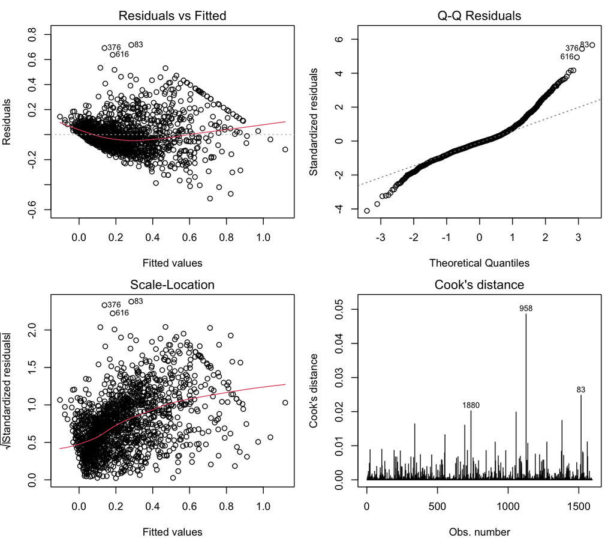

```r
par(mfrow = c(2, 2), mar = c(4, 4, 2, 1))
plot(ols_fit, which = c(1, 2, 3, 4))
```

```r
par(mfrow = c(1, 1))

bp <- lmtest::bptest(ols_fit)
sw <- shapiro.test(residuals(ols_fit))
cd <- cooks.distance(ols_fit)

tab_assump <- tibble::tibble(
  `Kiểm định / chỉ tiêu` = c(
    "Breusch–Pagan (phương sai đồng nhất)",
    "Shapiro–Wilk (phần dư chuẩn)",
    "Cook's D lớn nhất",
    "Số quan sát $D_i > 4/n$",
    "Số quan sát $D_i > 0.5$"),
  `Kết quả` = c(
    sprintf("BP = %.1f, p %s", bp$statistic, format.pval(bp$p.value, eps = 1e-16)),
    sprintf("W = %.3f, p %s", sw$statistic, format.pval(sw$p.value, eps = 1e-16)),
    round(max(cd), 3), sum(cd > 4 / nrow(df_train)), sum(cd > 0.5))
)
kb(tab_assump, caption = "Kiểm định giả định của mô hình OLS.")
```

Kiểm định giả định của mô hình OLS.

| Kiểm định / chỉ tiêu | Kết quả |
| --- | --- |
| Breusch–Pagan (phương sai đồng nhất) | BP = 307.5, p < 1e-16 |
| Shapiro–Wilk (phần dư chuẩn) | W = 0.935, p < 1e-16 |
| Cook’s D lớn nhất | 0.049 |
| Số quan sát $D_i &gt; 4/n$ | 118 |
| Số quan sát $D_i &gt; 0.5$ | 0 |

**Nhận xét.**

- **Phương sai không đồng nhất**: Breusch–Pagan bác bỏ mạnh $H_0$ ($p < 10^{-16}$); đồ thị Scale–Location cho thấy phương sai phần dư tăng theo giá trị dự đoán — điều thường gặp khi biến phản hồi lệch phải và bị chặn dưới tại 0.
- **Phần dư không chuẩn**: Shapiro–Wilk bác bỏ tính chuẩn ($p < 10^{-16}$), Q–Q plot lệch ở hai đuôi (một phần do 2.2% quan sát bị dồn tại trần $y = 1$).
- **Hệ quả**: hai vi phạm trên làm **sai số chuẩn và các kiểm định $t$/F của OLS không còn đáng tin**, nhưng **không làm chệch giá trị dự đoán điểm** $\hat{y}$ — mà so sánh mô hình ở báo cáo này dựa trên sai số dự đoán ngoài mẫu, nên hướng phân tích vẫn hợp lệ. Nếu mục tiêu là suy diễn hệ số, cần sai số chuẩn vững (robust/sandwich).
- **Quan sát ảnh hưởng**: khoảng cách Cook lớn nhất chỉ 0.049 — thấp hơn ngưỡng nghiêm trọng 0.5 hơn một bậc; 118 quan sát vượt ngưỡng thô $4/n$ nhưng không quan sát nào chi phối kết quả ước lượng. Điều này **củng cố quyết định giữ toàn bộ quan sát** ở Mục 3.5: các giá trị “ngoại lai” phân tán đều, không có điểm đòn bẩy đơn lẻ nào bóp méo mô hình.

## 7.2 Ridge Regression

Ridge giải bài toán phạt chuẩn $\ell_2$ (trên biến đã chuẩn hóa):

$$\hat{\boldsymbol\beta}^{ridge}_\lambda = \arg\min_{\boldsymbol\beta}\
\lVert \mathbf{y} - \mathbf{X}\boldsymbol\beta \rVert_2^2 + \lambda
\lVert \boldsymbol\beta \rVert_2^2
= (\mathbf{X}^\top\mathbf{X} +
\lambda\mathbf{I})^{-1}\mathbf{X}^\top\mathbf{y}, \qquad \lambda > 0.$$

Cộng $\lambda\mathbf{I}$ nâng mọi trị riêng của $\mathbf{X}^\top\mathbf{X}$ từ $\lambda_j$ lên $\lambda_j + \lambda > 0$, nên ma trận **luôn khả nghịch** kể cả khi $\mathbf{X}^\top\mathbf{X}$ suy biến — đây là “liều thuốc” trực tiếp cho vấn đề $\lambda_{\min} \approx 0$ của dữ liệu này. Hệ số bị co (shrinkage) trơn về 0 nhưng không bao giờ bằng 0 đúng.

## 7.3 LASSO

LASSO thay phạt $\ell_2$ bằng $\ell_1$:

$$\hat{\boldsymbol\beta}^{lasso}_\lambda = \arg\min_{\boldsymbol\beta}\
\frac{1}{2n}\lVert \mathbf{y} - \mathbf{X}\boldsymbol\beta \rVert_2^2 +
\lambda \lVert \boldsymbol\beta \rVert_1.$$

Do quả cầu $\ell_1$ có các “góc” nằm trên trục tọa độ, nghiệm tối ưu thường chạm góc — tức **một số hệ số bằng 0 đúng**: LASSO vừa co hệ số vừa **chọn biến** tự động.

## 7.4 Chọn tham số phạt bằng kiểm chứng chéo

$\lambda$ của cả hai mô hình được chọn bằng kiểm chứng chéo 10-fold trên tập huấn luyện, dùng **cùng một phân hoạch fold** (`foldid`) để hai đường cong CV so sánh được với nhau. Ta báo cáo cả $\lambda_{\min}$ (cực tiểu sai số CV) và $\lambda_{1se}$ (quy tắc một sai số chuẩn).

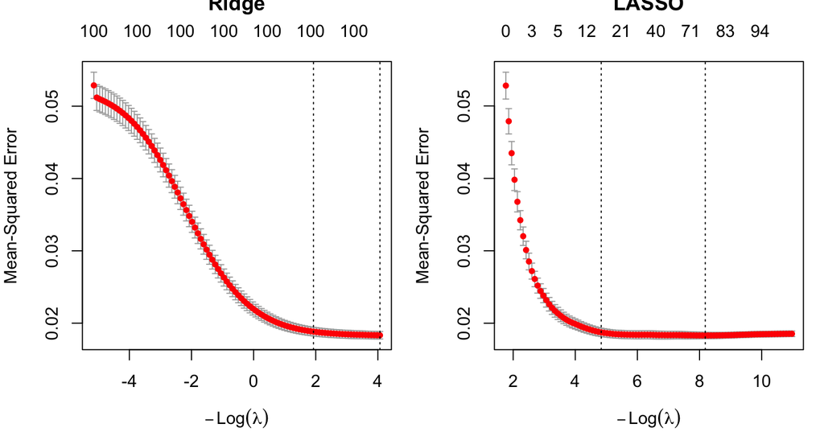

```r
library(glmnet)
Xm_train <- as.matrix(X_train)
Xm_val   <- as.matrix(X_val)

set.seed(SEED)
foldid <- sample(rep(1:10, length.out = nrow(Xm_train)))

cv_ridge <- cv.glmnet(Xm_train, y_train, alpha = 0, foldid = foldid, standardize = TRUE)
cv_lasso <- cv.glmnet(Xm_train, y_train, alpha = 1, foldid = foldid, standardize = TRUE)

par(mfrow = c(1, 2), mar = c(4, 4, 3, 1))
plot(cv_ridge); title("Ridge", line = 2.5)
plot(cv_lasso); title("LASSO", line = 2.5)
```

```r
par(mfrow = c(1, 1))

nz_min <- sum(coef(cv_lasso, s = "lambda.min")[-1] != 0)
nz_1se <- sum(coef(cv_lasso, s = "lambda.1se")[-1] != 0)

tab_lambda <- tibble::tibble(
  `Mô hình` = c("Ridge", "Ridge", "LASSO", "LASSO"),
  `Quy tắc` = c("$\\lambda_{\\min}$", "$\\lambda_{1se}$", "$\\lambda_{\\min}$", "$\\lambda_{1se}$"),
  `$\\lambda$` = signif(c(cv_ridge$lambda.min, cv_ridge$lambda.1se,
                          cv_lasso$lambda.min, cv_lasso$lambda.1se), 3),
  `MSE (CV)` = signif(c(min(cv_ridge$cvm), cv_ridge$cvm[cv_ridge$lambda == cv_ridge$lambda.1se],
                        min(cv_lasso$cvm), cv_lasso$cvm[cv_lasso$lambda == cv_lasso$lambda.1se]), 4),
  `Số hệ số khác 0` = c(ncol(Xm_train), ncol(Xm_train), nz_min, nz_1se)
)
kb(tab_lambda, caption = "Tham số phạt chọn bằng kiểm chứng chéo 10-fold (cùng foldid).")
```

Tham số phạt chọn bằng kiểm chứng chéo 10-fold (cùng foldid).

| Mô hình | Quy tắc | $\lambda$ | MSE (CV) | Số hệ số khác 0 |
| --- | --- | --- | --- | --- |
| Ridge | $\lambda_{\min}$ | 0.0171 | 0.0183 | 100 |
| Ridge | $\lambda_{1se}$ | 0.1460 | 0.0188 | 100 |
| LASSO | $\lambda_{\min}$ | 0.0003 | 0.0183 | 76 |
| LASSO | $\lambda_{1se}$ | 0.0080 | 0.0187 | 14 |

**Nhận xét.** Với Ridge, $\lambda_{\min} = 0.0171$ khá nhỏ — dữ liệu với $n = 1595 \gg p = 100$ không đòi hỏi co hệ số quá mạnh. Với LASSO, $\lambda_{\min} = 2.79\times 10^{-4}$ giữ 76 biến, còn $\lambda_{1se} = 0.00795$ chỉ giữ **14 biến** — một mô hình cực gọn sẽ rất hữu ích khi diễn giải (Mục 10). Để so sánh khả năng dự đoán thuần túy ở mục sau, ta dùng $\lambda_{\min}$ cho cả hai mô hình (đây là giá trị tối ưu hóa sai số CV — quyết định vẫn chỉ dựa trên tập huấn luyện); các phương án $\lambda_{1se}$ được báo cáo kèm để tham khảo.

# 8 Đánh giá và so sánh mô hình trên tập kiểm định

Ba chỉ số đánh giá trên tập kiểm định ($n_{val} = 399$), với $\hat y_i$ là giá trị dự đoán:

$$\mathrm{RMSE} = \sqrt{\tfrac{1}{n}\textstyle\sum_i (y_i - \hat y_i)^2},
\qquad
\mathrm{MAE} = \tfrac{1}{n}\textstyle\sum_i |y_i - \hat y_i|, \qquad
R^2 = 1 - \frac{\sum_i (y_i - \hat y_i)^2}{\sum_i (y_i - \bar
y_{val})^2}.$$

RMSE phạt nặng sai số lớn (bình phương), MAE bền vững hơn với sai số cực đoan; $R^2$ ở đây là tỷ lệ phương sai của $y$ trên tập kiểm định được mô hình giải thích (quy ước $\bar y_{val}$ ở mẫu số — so mô hình với “dự đoán bằng trung bình” trên chính tập kiểm định).

```r
rmse_f <- function(o, p) sqrt(mean((o - p)^2))
mae_f  <- function(o, p) mean(abs(o - p))
r2_f   <- function(o, p) 1 - sum((o - p)^2) / sum((o - mean(o))^2)
mets   <- function(o, p) c(RMSE = rmse_f(o, p), MAE = mae_f(o, p), R2 = r2_f(o, p))

pred_ols       <- predict(ols_fit, newdata = X_val)
pred_ridge     <- as.numeric(predict(cv_ridge, Xm_val, s = "lambda.min"))
pred_lasso     <- as.numeric(predict(cv_lasso, Xm_val, s = "lambda.min"))
pred_ridge_1se <- as.numeric(predict(cv_ridge, Xm_val, s = "lambda.1se"))
pred_lasso_1se <- as.numeric(predict(cv_lasso, Xm_val, s = "lambda.1se"))

kq <- rbind(
  `PCR (k = 11)`                 = mets(y_val, pred_pcr_val),
  `OLS`                          = mets(y_val, pred_ols),
  `Ridge ($\\lambda_{\\min}$)`   = mets(y_val, pred_ridge),
  `LASSO ($\\lambda_{\\min}$)`   = mets(y_val, pred_lasso)
)
kq_df <- tibble::tibble(`Mô hình` = rownames(kq)) |> bind_cols(as.data.frame(round(kq, 4)))

best_rmse <- which.min(kq[, "RMSE"])
kb(kq_df, caption = "So sánh bốn mô hình trên tập kiểm định.") |>
  row_spec(best_rmse, bold = TRUE, background = "#EAF2E3")
```

So sánh bốn mô hình trên tập kiểm định.

| Mô hình | RMSE | MAE | R2 |
| --- | --- | --- | --- |
| PCR (k = 11) | 0.1489 | 0.1083 | 0.6266 |
| OLS | 0.1386 | 0.0990 | 0.6765 |
| Ridge ($\lambda_{\min}$) | 0.1396 | 0.1005 | 0.6714 |
| LASSO ($\lambda_{\min}$) | 0.1379 | 0.0990 | 0.6794 |

```r
kq_1se <- rbind(
  `Ridge ($\\lambda_{1se}$)` = mets(y_val, pred_ridge_1se),
  `LASSO ($\\lambda_{1se}$)` = mets(y_val, pred_lasso_1se)
)
kb(tibble::tibble(`Mô hình` = rownames(kq_1se)) |>
     bind_cols(as.data.frame(round(kq_1se, 4))),
   caption = "Tham khảo: các phương án $\\lambda_{1se}$ gọn hơn.")
```

Tham khảo: các phương án $\lambda_{1se}$ gọn hơn.

| Mô hình | RMSE | MAE | R2 |
| --- | --- | --- | --- |
| Ridge ($\lambda_{1se}$) | 0.1443 | 0.1038 | 0.6489 |
| LASSO ($\lambda_{1se}$) | 0.1447 | 0.1021 | 0.6472 |

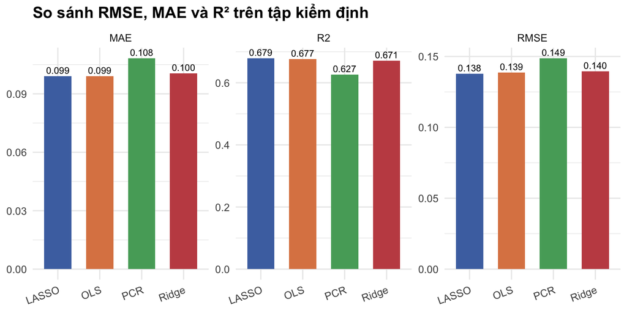

```r
as.data.frame(kq) |>
  tibble::rownames_to_column("Mô hình") |>
  mutate(`Mô hình` = c("PCR", "OLS", "Ridge", "LASSO")) |>
  pivot_longer(-`Mô hình`, names_to = "Chỉ số", values_to = "Giá trị") |>
  ggplot(aes(`Mô hình`, `Giá trị`, fill = `Mô hình`)) +
  geom_col(show.legend = FALSE, width = 0.65) +
  geom_text(aes(label = sprintf("%.3f", `Giá trị`)), vjust = -0.4, size = 3) +
  facet_wrap(~`Chỉ số`, scales = "free_y") +
  scale_fill_manual(values = c("#4C72B0", "#DD8452", "#55A868", "#C44E52")) +
  labs(title = "So sánh RMSE, MAE và R² trên tập kiểm định", x = NULL, y = NULL) +
  theme(axis.text.x = element_text(angle = 20, hjust = 1))
```

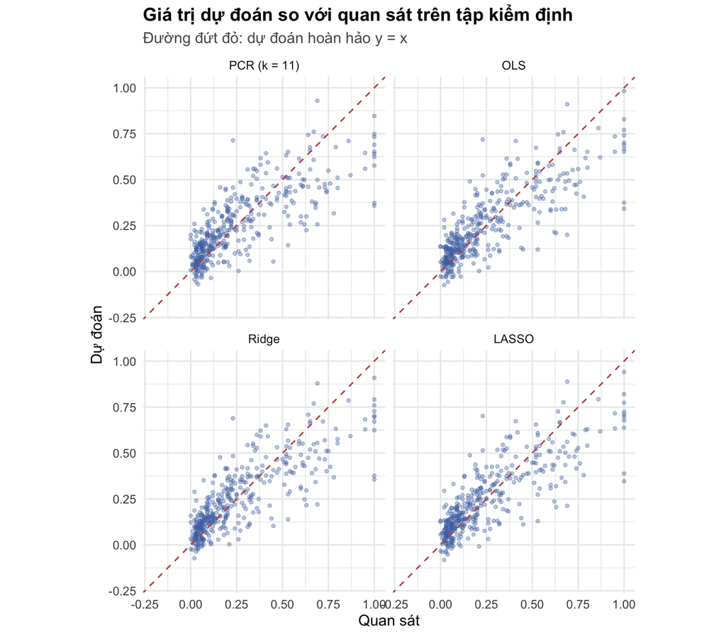

```r
tibble::tibble(
  `Quan sát` = rep(y_val, 4),
  `Dự đoán` = c(pred_pcr_val, pred_ols, pred_ridge, pred_lasso),
  `Mô hình` = rep(c("PCR (k = 11)", "OLS", "Ridge", "LASSO"), each = length(y_val))
) |>
  mutate(`Mô hình` = factor(`Mô hình`, levels = c("PCR (k = 11)", "OLS", "Ridge", "LASSO"))) |>
  ggplot(aes(`Quan sát`, `Dự đoán`)) +
  geom_point(alpha = 0.35, size = 1, color = "#4C72B0") +
  geom_abline(slope = 1, intercept = 0, color = "#C44E52", linetype = 2) +
  facet_wrap(~`Mô hình`) +
  coord_equal(xlim = c(-0.2, 1), ylim = c(-0.2, 1)) +
  labs(title = "Giá trị dự đoán so với quan sát trên tập kiểm định",
       subtitle = "Đường đứt đỏ: dự đoán hoàn hảo y = x")
```

**Nhận xét.**

- **LASSO ($\lambda_{\min}$) đạt kết quả tốt nhất** trên cả ba chỉ số (RMSE $= 0.1379$, $R^2 = 0.6794$), nhưng khoảng cách với OLS (RMSE $= 0.1386$) và Ridge là **rất nhỏ** — chênh lệch RMSE dưới 0.002, tức dưới 1% độ lệch chuẩn của $y$ trên tập kiểm định (0.244). Với $n \gg p$, OLS tuy có hệ số bất ổn nhưng tổng thể dự đoán vẫn cạnh tranh; lợi ích của regularization ở đây là có thật nhưng khiêm tốn.
- **PCR ($k = 11$) kém nhất** (RMSE $= 0.1489$, $R^2 = 0.6266$): giữ 11 thành phần “nén” được ~79% phương sai của $\mathbf{X}$ nhưng đã bỏ đi một phần thông tin dự đoán nằm ở các thành phần sau — minh họa đúng điểm yếu lý thuyết của PCR (chọn thành phần không nhìn $y$, sẽ phân tích sâu ở Mục 11).
- Trên đồ thị dự đoán–quan sát, cả bốn mô hình đều có dạng **“cụp” ở hai biên**: dự đoán vượt 0 ở nhóm tội phạm thấp và không chạm tới nhóm bị dồn tại trần $y = 1$ — hệ quả trực tiếp của biến phản hồi bị chặn trên $[0,1]$ mà mô hình tuyến tính không ràng buộc — Mục 12 sẽ xử lý trực tiếp điểm này.
- MAE (0.099 với LASSO) nhỏ hơn RMSE đáng kể ở mọi mô hình, cho thấy phần lớn sai số là nhỏ nhưng có một nhóm sai số lớn (các cộng đồng cực đoan) kéo RMSE lên.

# 9 Phân tích các thành phần chính qua ma trận tải

Vector tải $\mathbf{v}_j$ cho biết mỗi thành phần chính là tổ hợp tuyến tính nào của các biến gốc (đã chuẩn hóa); vì $\lVert\mathbf{v}_j\rVert = 1$, độ lớn $|v_{ij}|$ đo mức đóng góp tương đối của biến $i$ vào thành phần $j$. Ta xét 4 thành phần đầu (chiếm 58.7% phương sai) qua 10 biến có $|v_{ij}|$ lớn nhất của mỗi thành phần, đồng thời tính **tương quan giữa điểm thành phần (scores) với $y$** để đo mức liên quan của từng thành phần tới tội phạm.

```r
V <- unclass(pcr_fit$loadings)[, 1:k_pcr]

top_load <- function(j, m = 10) {
  lj <- sort(abs(V[, j]), decreasing = TRUE)[1:m]
  tibble::tibble(`Biến` = names(lj), `Loading` = round(V[names(lj), j], 3))
}

bind_cols(
  top_load(1) |> rename(`Biến (PC1)` = `Biến`, `v1` = Loading),
  top_load(2) |> rename(`Biến (PC2)` = `Biến`, `v2` = Loading)
) |>
  kb(caption = sprintf(
    "10 biến tải lớn nhất của PC1 (PVE %.1f%%) và PC2 (PVE %.1f%%).",
    100 * pve[1], 100 * pve[2]))
```

10 biến tải lớn nhất của PC1 (PVE 25.2%) và PC2 (PVE 16.5%).

| Biến (PC1) | v1 | Biến (PC2) | v2 |
| --- | --- | --- | --- |
| medFamInc | -0.184 | PctRecImmig8 | -0.221 |
| medIncome | -0.183 | PctRecImmig10 | -0.221 |
| PctKids2Par | -0.174 | PctRecImmig5 | -0.219 |
| pctWInvInc | -0.174 | PctRecentImmig | -0.216 |
| PctPopUnderPov | 0.173 | PctForeignBorn | -0.213 |
| PctYoungKids2Par | -0.171 | PctSpeakEnglOnly | 0.192 |
| PctFam2Par | -0.171 | PctNotSpeakEnglWell | -0.187 |
| perCapInc | -0.170 | PctPersDenseHous | -0.175 |
| PctHousNoPhone | 0.165 | racePctAsian | -0.166 |
| pctWPubAsst | 0.164 | racePctHisp | -0.161 |

```r
bind_cols(
  top_load(3) |> rename(`Biến (PC3)` = `Biến`, `v3` = Loading),
  top_load(4) |> rename(`Biến (PC4)` = `Biến`, `v4` = Loading)
) |>
  kb(caption = sprintf(
    "10 biến tải lớn nhất của PC3 (PVE %.1f%%) và PC4 (PVE %.1f%%).",
    100 * pve[3], 100 * pve[4]))
```

10 biến tải lớn nhất của PC3 (PVE 9.4%) và PC4 (PVE 7.5%).

| Biến (PC3) | v3 | Biến (PC4) | v4 |
| --- | --- | --- | --- |
| PersPerOccupHous | 0.259 | PctSameCity85 | 0.259 |
| PersPerFam | 0.237 | agePct12t29 | -0.251 |
| householdsize | 0.226 | PctSameHouse85 | 0.247 |
| PersPerOwnOccHous | 0.225 | agePct16t24 | -0.242 |
| PersPerRentOccHous | 0.211 | agePct12t21 | -0.238 |
| PctLargHouseOccup | 0.210 | agePct65up | 0.195 |
| PctLargHouseFam | 0.178 | pctWSocSec | 0.186 |
| HousVacant | -0.166 | PctSameState85 | 0.178 |
| numbUrban | -0.149 | PctImmigRec5 | -0.177 |
| population | -0.148 | PctImmigRecent | -0.177 |

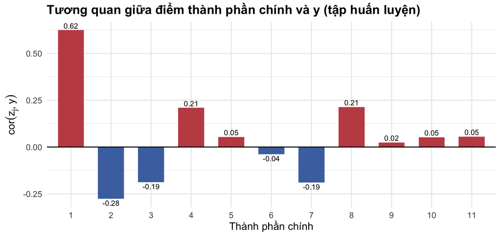

```r
scores_train <- pcr_fit$scores[, 1:k_pcr]
cor_pc_y <- as.numeric(cor(scores_train, y_train))

tibble::tibble(PC = factor(1:k_pcr), r = cor_pc_y) |>
  ggplot(aes(PC, r, fill = r > 0)) +
  geom_col(show.legend = FALSE, width = 0.65) +
  geom_hline(yintercept = 0) +
  scale_fill_manual(values = c(`TRUE` = "#C44E52", `FALSE` = "#4C72B0")) +
  geom_text(aes(label = sprintf("%.2f", r), vjust = ifelse(r > 0, -0.35, 1.3)), size = 3) +
  labs(title = "Tương quan giữa điểm thành phần chính và y (tập huấn luyện)",
       x = "Thành phần chính", y = expression(cor(z[j], y)))
```

**Diễn giải các thành phần** (dựa trên các bảng tải ở trên, đối chiếu bảng nhóm biến Mục 2.3):

- **PC1 — trục “bất lợi kinh tế và cấu trúc gia đình”** (PVE 25.2%): tải **âm** với mọi biến thu nhập (`medFamInc`, `medIncome`, `pctWInvInc`, `perCapInc`) và biến gia đình đủ hai bố mẹ (`PctKids2Par`, `PctFam2Par`); tải **dương** với nghèo đói và trợ cấp (`PctPopUnderPov`, `pctWPubAsst`, `PctHousNoPhone`). Giá trị PC1 cao ⟺ cộng đồng nghèo, ít gia đình nguyên vẹn. Đây cũng là thành phần liên hệ mạnh nhất với tội phạm: $\mathrm{cor}(z_1, y) = 0.62$ — **một trục duy nhất tóm tắt gần như toàn bộ tín hiệu chính** mà EDA đã thấy ở Mục 3.3.
- **PC2 — trục “nhập cư và ngôn ngữ”** (PVE 16.5%): tải âm đồng loạt với các biến nhập cư gần đây (`PctRecImmig5/8/10`, `PctForeignBorn`, `PctNotSpeakEnglWell`) và dương với `PctSpeakEnglOnly`; giá trị cao ⟺ cộng đồng “bản địa”, ít dân nhập cư. Tương quan với $y$ ở mức vừa ($-0.28$).
- **PC3 — trục “quy mô hộ và mật độ ở”** (PVE 9.4%): các biến người/hộ (`PersPerOccupHous`, `PersPerFam`, `householdsize`, `PctLargHouseOccup`) tải dương mạnh.
- **PC4 — trục “ổn định cư trú và cơ cấu tuổi”** (PVE 7.5%): dương với các biến ở lâu một chỗ (`PctSameCity85`, `PctSameHouse85`) và dân số già (`agePct65up`, `pctWSocSec`), âm với các nhóm tuổi trẻ (`agePct12t29`, `agePct16t24`).

**Nhận xét quan trọng cho PCR.** Biểu đồ tương quan thành phần–$y$ bộc lộ đúng “gót chân Achilles” của PCR: mức liên quan tới $y$ **không giảm dần theo thứ tự phương sai**. Chẳng hạn PC8 chỉ chiếm 2.9% phương sai nhưng có $\mathrm{cor}(z_8, y) = 0.21$ — ngang với PC4 và cao hơn hẳn PC5, PC6 (gần như bằng 0). PCA sắp xếp các thành phần theo lượng phương sai của $\mathbf{X}$, không theo giá trị dự đoán cho $y$; vì vậy quy tắc “giữ $k$ thành phần đầu” có thể vừa giữ những thành phần vô dụng, vừa cắt mất thông tin nằm ở các thành phần sau — sẽ được định lượng thêm ở Mục 11.

# 10 Chuyển hệ số PCR về không gian biến gốc

## 10.1 Công thức chuyển đổi

Mô hình PCR trên không gian thành phần là $\hat y = \bar y + \mathbf{z}^\top\hat{\boldsymbol\gamma}$ với $\mathbf{z} = \mathbf{V}_k^\top \mathbf{x}_s$. Thay ngược, hệ số trên **biến chuẩn hóa** là $\hat{\boldsymbol\beta}^{std} = \mathbf{V}_k\hat{\boldsymbol\gamma}$, và quy về **thang đo gốc** của biến $j$ (chia cho độ lệch chuẩn huấn luyện $s_j$, điều chỉnh hệ số chặn):

$$\hat\beta_j = \frac{(\mathbf{V}_k\hat{\boldsymbol\gamma})_j}{s_j},
\qquad
\hat\beta_0 = \bar y_{train} - \sum_{j=1}^{p} \hat\beta_j\,\bar
x_{j,train}.$$

Do các cột điểm thành phần trực giao, $\hat\gamma_j = \mathbf{z}_j^\top\mathbf{y} / \mathbf{z}_j^\top\mathbf{z}_j$ tính được từng thành phần độc lập. Ta thực hiện phép chuyển đổi thủ công rồi **kiểm chứng bằng số**: dự đoán từ $(\hat\beta_0, \hat{\boldsymbol\beta})$ phải trùng dự đoán của mô hình `pls` đến sai số dấu phẩy động.

```r
gamma_hat <- drop(crossprod(scores_train, y_train) / colSums(scores_train^2))
beta_std  <- drop(V %*% gamma_hat)

x_bar <- colMeans(X_train)
s_x   <- apply(X_train, 2, sd)
beta_orig <- beta_std / s_x
beta_0    <- mean(y_train) - sum(beta_orig * x_bar)

pred_manual <- as.numeric(as.matrix(X_val) %*% beta_orig + beta_0)
sai_so_khop <- max(abs(pred_manual - pred_pcr_val))
sai_so_khop
```

```
## [1] 1.465494e-14
```

Sai số lớn nhất giữa hai cách tính là $1.47e-14$ — cỡ sai số làm tròn của số thực dấu phẩy động, xác nhận phép chuyển đổi chính xác.

## 10.2 Diễn giải hệ số trên các biến gốc

Để so sánh mức ảnh hưởng **giữa các biến**, ta dùng $\hat\beta^{std}$ (hệ số trên biến chuẩn hóa — “tăng 1 độ lệch chuẩn của $X_j$ làm $\hat y$ thay đổi $\hat\beta^{std}_j$”), vì nó không phụ thuộc thang đo từng biến.

```r
ord <- order(abs(beta_std), decreasing = TRUE)
tab_beta <- tibble::tibble(
  `Biến` = names(beta_std)[ord[1:15]],
  `$\\hat\\beta^{std}$` = round(beta_std[ord[1:15]], 4),
  `$\\hat\\beta$ (thang gốc)` = round(beta_orig[ord[1:15]], 4)
)
kb(tab_beta, caption = "15 biến có hệ số PCR (chuẩn hóa) lớn nhất về trị tuyệt đối.")
```

15 biến có hệ số PCR (chuẩn hóa) lớn nhất về trị tuyệt đối.

| Biến | $\hat\beta^{std}$ | $\hat\beta$ (thang gốc) |
| --- | --- | --- |
| racepctblack | 0.0197 | 0.0774 |
| racePctWhite | -0.0169 | -0.0703 |
| PctIlleg | 0.0162 | 0.0711 |
| PctKids2Par | -0.0141 | -0.0679 |
| PctTeen2Par | -0.0136 | -0.0710 |
| PctFam2Par | -0.0130 | -0.0642 |
| PctYoungKids2Par | -0.0126 | -0.0582 |
| FemalePctDiv | 0.0116 | 0.0658 |
| TotalPctDiv | 0.0113 | 0.0615 |
| PctVacantBoarded | 0.0109 | 0.0514 |
| MalePctDivorce | 0.0104 | 0.0568 |
| pctWFarmSelf | -0.0090 | -0.0430 |
| pctWPubAsst | 0.0086 | 0.0388 |
| pctWInvInc | -0.0078 | -0.0435 |
| MedRentPctHousInc | 0.0071 | 0.0421 |

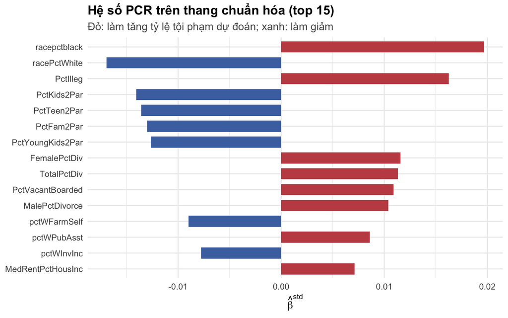

```r
tibble::tibble(bien = names(beta_std)[ord[1:15]], beta = beta_std[ord[1:15]]) |>
  ggplot(aes(x = reorder(bien, abs(beta)), y = beta, fill = beta > 0)) +
  geom_col(show.legend = FALSE, width = 0.7) +
  coord_flip() +
  scale_fill_manual(values = c(`TRUE` = "#C44E52", `FALSE` = "#4C72B0")) +
  labs(title = "Hệ số PCR trên thang chuẩn hóa (top 15)",
       subtitle = "Đỏ: làm tăng tỷ lệ tội phạm dự đoán; xanh: làm giảm",
       x = NULL, y = expression(hat(beta)^{std}))
```

**Diễn giải.** Các hệ số lớn nhất tập trung vào ba cụm nội dung, dấu hoàn toàn nhất quán với phân tích tương quan ở Mục 3.3:

- **Cấu trúc gia đình** — cụm mạnh nhất: `PctIlleg` (con ngoài giá thú, $+$), bốn biến gia đình đủ hai bố mẹ `PctKids2Par`, `PctTeen2Par`, `PctFam2Par`, `PctYoungKids2Par` (đều $-$), và cụm ly hôn `FemalePctDiv`, `TotalPctDiv`, `MalePctDivorce` (đều $+$). Đáng chú ý, PCR **phân bổ trọng số gần như đều** cho cả bốn biến “hai bố mẹ” vốn tương quan với nhau trên 0.9 — hệ quả tự nhiên của việc ước lượng qua các thành phần chung thay vì từng biến riêng (grouping effect).
- **Cơ cấu chủng tộc**: `racepctblack` ($+$) và `racePctWhite` ($-$) đứng đầu bảng. Cần nhấn mạnh: đây là **liên hệ tương quan trong dữ liệu quan sát, tuyệt đối không phải quan hệ nhân quả**; trong dữ liệu Hoa Kỳ 1990, biến chủng tộc gắn chặt với các bất lợi cấu trúc (nghèo đói, phân biệt trong nhà ở/việc làm) — mô hình không tách được các hiệu ứng này, và việc dùng biến chủng tộc để ra quyết định chính sách sẽ là ngụy biện sinh thái (xem thêm phần Hạn chế ở Mục 13).
- **Suy thoái nhà ở**: `PctVacantBoarded` (nhà bỏ hoang bịt ván, $+$), `MedRentPctHousInc` (gánh nặng tiền thuê, $+$) — phù hợp với lý thuyết “cửa sổ vỡ” trong xã hội học tội phạm.

## 10.3 Đối chiếu với tập biến LASSO chọn

LASSO với $\lambda_{1se}$ giữ đúng 14 biến — một “bản tóm tắt thưa” để đối chiếu với bức tranh của PCR:

```r
coef_lasso_1se <- coef(cv_lasso, s = "lambda.1se")[-1, 1]
sel_lasso <- names(coef_lasso_1se)[coef_lasso_1se != 0]

tab_lasso <- tibble::tibble(
  `Biến` = sel_lasso,
  `Hệ số LASSO ($\\lambda_{1se}$)` = round(coef_lasso_1se[sel_lasso], 4),
  `Thuộc top 15 |β| của PCR?` = ifelse(sel_lasso %in% names(beta_std)[ord[1:15]], "Có", "—")
) |> arrange(desc(abs(`Hệ số LASSO ($\\lambda_{1se}$)`)))
kb(tab_lasso, caption = "14 biến được LASSO (λ 1se) giữ lại và đối chiếu với PCR.")
```

14 biến được LASSO (λ 1se) giữ lại và đối chiếu với PCR.

| Biến | Hệ số LASSO ($\lambda_{1se}$) | Thuộc top 15 &#124;β&#124; của PCR? |
| --- | --- | --- |
| PctKids2Par | -0.2909 | Có |
| PctIlleg | 0.1944 | Có |
| racePctWhite | -0.1222 | Có |
| HousVacant | 0.1211 | — |
| MalePctDivorce | 0.1124 | Có |
| PctPersDenseHous | 0.0984 | — |
| NumStreet | 0.0813 | — |
| racepctblack | 0.0553 | Có |
| PctWorkMom | -0.0501 | — |
| PctHousOccup | -0.0306 | — |
| pctUrban | 0.0229 | — |
| agePct12t29 | -0.0189 | — |
| PctVacantBoarded | 0.0130 | Có |
| LemasPctOfficDrugUn | 0.0025 | — |

**Nhận xét.** Hai phương pháp với triết lý đối lập — PCR “gộp” các biến tương quan vào thành phần chung, LASSO “tỉa” chỉ giữ một đại diện mỗi cụm — **hội tụ về cùng một câu chuyện**: 6 biến trùng nhau giữa hai danh sách (`racepctblack`, `racePctWhite`, `PctKids2Par`, `PctIlleg`, `MalePctDivorce`, `PctVacantBoarded`). Khác biệt minh họa rõ tính chất từng phương pháp: thay vì rải trọng số cho cả bốn biến “hai bố mẹ” như PCR, LASSO dồn toàn bộ vào một mình `PctKids2Par` (hệ số $-0.291$ — lớn nhất bảng) và loại ba biến gần trùng còn lại. Đây chính là điểm cần lưu ý khi diễn giải LASSO dưới đa cộng tuyến: biến bị loại **không có nghĩa là không quan trọng**, nó chỉ bị biến đại diện “hút” mất vai trò.

# 11 Thảo luận và lựa chọn mô hình

## 11.1 Vì sao PCR thua trên bộ dữ liệu này? Một phân tích độ nhạy

Kết quả Mục 8 cho thấy PCR với $k = 11$ kém các mô hình còn lại một khoảng rõ rệt. Để xác định nguyên nhân, ta tính RMSE trên tập kiểm định của PCR theo nhiều mức $k$ (dùng lại mô hình 100 thành phần đã khớp ở Mục 6.4):

```r
tab_sens <- tibble::tibble(
  k = c(11, 25, 50, 77, 100),
  RMSE = sapply(c(11, 25, 50, 77, 100), function(k) {
    p <- as.numeric(predict(pcr_cv, newdata = X_val, ncomp = k))
    rmse_f(y_val, p)
  })
) |>
  mutate(`So với OLS` = sprintf("%+.4f", RMSE - rmse_f(y_val, pred_ols)))
kb(tab_sens, caption = "RMSE kiểm định của PCR theo số thành phần giữ lại.")
```

RMSE kiểm định của PCR theo số thành phần giữ lại.

| k | RMSE | So với OLS |
| --- | --- | --- |
| 11 | 0.1489 | +0.0103 |
| 25 | 0.1447 | +0.0062 |
| 50 | 0.1417 | +0.0031 |
| 77 | 0.1387 | +0.0001 |
| 100 | 0.1386 | +0.0000 |

**Nhận xét.** RMSE giảm **đơn điệu và chậm** khi tăng $k$: phải giữ tới $k \approx 77$ thành phần PCR mới đuổi kịp OLS, và tại $k = 100$ PCR trùng khớp OLS đúng như lý thuyết (giữ đủ thành phần thì phép quay trực giao không thay đổi không gian cột). Kết hợp với biểu đồ $\mathrm{cor}(z_j, y)$ ở Mục 9, nguyên nhân đã rõ: **tín hiệu dự đoán không tập trung ở vài thành phần phương sai lớn** mà rải rác cả ở các thành phần sau (PC7, PC8…). Việc nén 100 biến xuống 11 thành phần tiết kiệm được 89 tham số nhưng trả giá bằng ~0.010 RMSE — trên bộ dữ liệu này, giảm chiều theo phương sai của $\mathbf{X}$ không “miễn phí” như kỳ vọng.

## 11.2 Ưu điểm và hạn chế của từng phương pháp

Trong bối cảnh cụ thể của bài toán — $p = 100$ biến, đa cộng tuyến nghiêm trọng ($\kappa \approx 200$, 65 biến VIF > 10) nhưng $n = 1595 \gg p$:

[output not shown]

## 11.3 Đề xuất mô hình

Từ toàn bộ kết quả, ta đề xuất **LASSO** là mô hình cuối cùng, với hai cấu hình theo mục đích sử dụng:

- **Dự đoán**: LASSO với $\lambda_{\min} = 2.79\times 10^{-4}$ — tốt nhất trên cả ba chỉ số kiểm định (RMSE $0.1379$, MAE $0.099$, $R^2 = 0.6794$), đồng thời gọn hơn OLS (76/100 biến).
- **Diễn giải và truyền đạt**: LASSO với $\lambda_{1se}$ — chỉ 14 biến, mất ~0.007 RMSE, phù hợp khi cần một mô hình chính sách dễ giải thích.

Cần thẳng thắn: khoảng cách giữa LASSO, OLS và Ridge là **nhỏ và có thể không bền vững** qua các lần chia dữ liệu khác nhau (chênh lệch RMSE < 1% độ lệch chuẩn của $y$). Kết luận vững hơn là ở chiều ngược lại: **PCR với số thành phần chọn theo tiêu chuẩn thống kê là lựa chọn kém nhất cho mục tiêu dự đoán** trên bộ dữ liệu này — dù vẫn là công cụ mô tả cấu trúc dữ liệu có giá trị (Mục 9). Nếu muốn giữ tinh thần “hồi quy trên thành phần”, phương pháp đúng là **PLS (Partial Least Squares)** — xây thành phần bằng cách tối đa hóa hiệp phương sai với $y$ thay vì phương sai của riêng $\mathbf{X}$; nhận định này sẽ được kiểm chứng thực nghiệm ở Mục 12.

# 12 Thử nghiệm cải thiện mô hình

Mục này kiểm chứng bằng thực nghiệm các hướng cải thiện khả dĩ, trên **cùng phép chia dữ liệu** và cùng phân hoạch fold CV như các mục trước. Hai hướng xuất phát trực tiếp từ các chẩn đoán đã có; các hướng còn lại nhằm trả lời câu hỏi “mô hình tuyến tính đã chạm trần của dữ liệu chưa?”.

## 12.1 Biến đổi ổn định phương sai $\sqrt{y}$

Hai chẩn đoán ở các mục trước cùng chỉ về một hướng: biến phản hồi lệch phải mạnh (skewness 1.52, Mục 3.1) và phương sai phần dư tăng theo giá trị dự đoán (Breusch–Pagan $p < 10^{-16}$, Mục 7.1). Với dữ liệu dạng tỷ lệ đếm không âm, phép biến đổi căn bậc hai là **biến đổi ổn định phương sai** cổ điển (nếu $\mathrm{Var}(y) \propto E[y]$ như họ Poisson thì $\mathrm{Var}(\sqrt{y})$ xấp xỉ hằng số), đồng thời nén đuôi phải về gần đối xứng. Ta huấn luyện LASSO trên $\sqrt{y}$ rồi **bình phương ngược** dự đoán và đánh giá trên thang gốc để so sánh công bằng. Lưu ý một điểm lý thuyết: do bất đẳng thức Jensen, $(E[\sqrt{y}])^2 \le E[y]$, nên dự đoán bình phương ngược có xu hướng chệch xuống nhẹ ở kỳ vọng — đổi lại mô hình khớp cấu trúc phương sai tốt hơn; kết quả thực nghiệm sẽ phân xử.

## 12.2 Chặn dự đoán về miền khả thi $[0,1]$

Biến phản hồi luôn thuộc $[0,1]$ nhưng mô hình tuyến tính không bị ràng buộc (Mục 8 đã thấy các dự đoán âm). Đặt $\tilde p = \min(\max(p, 0), 1)$ — phép chiếu dự đoán $p$ lên $[0,1]$. Vì $y \in [0,1]$, ta luôn có

$$|\tilde p - y| \;\le\; |p - y| \quad \text{với mọi } y \in [0,1],$$

(chiếu lên tập lồi chứa $y$ không bao giờ đi xa $y$ hơn), nên RMSE và MAE **chỉ có thể tốt lên hoặc giữ nguyên** — một cải thiện “miễn phí” về mặt logic, không cần kiểm chứng chéo.

## 12.3 Các mô hình mở rộng đối chứng

- **PLS** — trả lời trực tiếp điểm yếu của PCR (Mục 11.1): thành phần được xây để tối đa hóa $\mathrm{Cov}(\mathbf{X}w, y)$ thay vì $\mathrm{Var}(\mathbf{X}w)$; số thành phần chọn bằng CV như PCR.
- **Elastic Net** — phạt hỗn hợp $\lambda\big[\alpha\lVert\beta\rVert_1 + (1-\alpha)\lVert\beta\rVert_2^2/2\big]$, quét $\alpha \in \{0.1, 0.3, 0.5, 0.7, 0.9\}$ với cùng `foldid`, chọn theo sai số CV.
- **GAM** — hồi quy cộng tính với spline $s(x_j)$ cho 14 biến LASSO-1se, kiểm tra xem quan hệ phi tuyến trơn có bị bỏ sót không.
- **Random Forest** — mô hình phi tuyến, phi tham số làm “mốc trần”: nếu RF không vượt được các mô hình tuyến tính thì phần tín hiệu phi tuyến còn lại là không đáng kể.

```r
# 1) LASSO trên sqrt(y), cùng foldid
cv_lasso_sqrt <- cv.glmnet(Xm_train, sqrt(y_train), alpha = 1, foldid = foldid)
p_sqrt <- pmax(as.numeric(predict(cv_lasso_sqrt, Xm_val, s = "lambda.min")), 0)^2
p_sqrt_clip <- pmin(p_sqrt, 1)

# 2) Clip baseline
p_lasso_clip <- pmin(pmax(pred_lasso, 0), 1)

# 3) PLS với CV chọn số thành phần
set.seed(SEED)
pls_cv <- plsr(y ~ ., data = df_train, scale = TRUE, validation = "CV", segments = 10)
k_pls <- selectNcomp(pls_cv, method = "onesigma", plot = FALSE)
rmsep_pls <- RMSEP(pls_cv, estimate = "CV")$val[1, 1, ]
k_pls_min <- which.min(rmsep_pls) - 1
p_pls_1se <- as.numeric(predict(pls_cv, newdata = X_val, ncomp = k_pls))
p_pls_min <- as.numeric(predict(pls_cv, newdata = X_val, ncomp = k_pls_min))

# 4) Elastic Net: quét alpha với cùng foldid
alphas <- seq(0.1, 0.9, by = 0.2)
cv_enet_list <- lapply(alphas, function(a)
  cv.glmnet(Xm_train, y_train, alpha = a, foldid = foldid))
best_a <- which.min(sapply(cv_enet_list, function(cv) min(cv$cvm)))
p_enet <- as.numeric(predict(cv_enet_list[[best_a]], Xm_val, s = "lambda.min"))

# 5) GAM trên 14 biến LASSO-1se
fml_gam <- as.formula(paste("y ~", paste(sprintf("s(%s, k = 5)", sel_lasso), collapse = " + ")))
gam_fit <- mgcv::gam(fml_gam, data = df_train, method = "REML")
p_gam <- pmin(pmax(as.numeric(predict(gam_fit, newdata = X_val)), 0), 1)

# 6) Random Forest
set.seed(SEED)
rf_fit <- ranger::ranger(y = y_train, x = X_train, num.trees = 1000,
                         mtry = floor(ncol(X_train) / 3), min.node.size = 5)
p_rf <- predict(rf_fit, X_val)$predictions
```

```r
kq_ct <- rbind(
  `LASSO (baseline, Mục 8)`            = mets(y_val, pred_lasso),
  `LASSO + chặn [0,1]`                 = mets(y_val, p_lasso_clip),
  `LASSO trên $\\sqrt{y}$`             = mets(y_val, p_sqrt),
  `LASSO trên $\\sqrt{y}$ + chặn`      = mets(y_val, p_sqrt_clip),
  `PLS (one-sigma)`                    = mets(y_val, p_pls_1se),
  `PLS (cực tiểu CV)`                  = mets(y_val, p_pls_min),
  `Elastic Net (α tốt nhất theo CV)`   = mets(y_val, p_enet),
  `GAM (14 biến LASSO-1se)`            = mets(y_val, p_gam),
  `Random Forest (1000 cây)`           = mets(y_val, p_rf)
)
tab_ct <- tibble::tibble(`Mô hình` = rownames(kq_ct)) |>
  bind_cols(as.data.frame(round(kq_ct, 4)))
kb(tab_ct, caption = "Các thử nghiệm cải thiện, đánh giá trên cùng tập kiểm định (thang gốc của y).") |>
  row_spec(which.min(kq_ct[, "RMSE"]), bold = TRUE, background = "#EAF2E3")
```

Các thử nghiệm cải thiện, đánh giá trên cùng tập kiểm định (thang gốc của y).

| Mô hình | RMSE | MAE | R2 |
| --- | --- | --- | --- |
| LASSO (baseline, Mục 8) | 0.1379 | 0.0990 | 0.6794 |
| LASSO + chặn [0,1] | 0.1376 | 0.0982 | 0.6811 |
| LASSO trên $\sqrt{y}$ | 0.1374 | 0.0915 | 0.6821 |
| LASSO trên $\sqrt{y}$ + chặn | 0.1372 | 0.0911 | 0.6829 |
| PLS (one-sigma) | 0.1477 | 0.1085 | 0.6321 |
| PLS (cực tiểu CV) | 0.1383 | 0.0994 | 0.6775 |
| Elastic Net (α tốt nhất theo CV) | 0.1380 | 0.0991 | 0.6793 |
| GAM (14 biến LASSO-1se) | 0.1380 | 0.0973 | 0.6789 |
| Random Forest (1000 cây) | 0.1415 | 0.0983 | 0.6624 |

**Nhận xét.**

- **Cải thiện thực sự đến từ việc tôn trọng cấu trúc của $y$**, không phải từ mô hình phức tạp hơn: LASSO trên $\sqrt{y}$ kèm chặn miền đạt RMSE $0.1372$ và đặc biệt **MAE giảm 8.0%** (từ 0.099 xuống 0.0911) so với LASSO gốc — đúng như kỳ vọng của một biến đổi ổn định phương sai: sai số ở vùng $y$ nhỏ (đa số quan sát) được thu hẹp rõ.
- **PLS xác nhận chẩn đoán về PCR**: với quy tắc one-sigma, PLS chỉ cần $k = 3$ thành phần để đạt mức mà PCR cần 11 thành phần, và với $k = 21$ đạt gần mức OLS — trong khi PCR cần ~77 (Mục 11.1). Thành phần “có giám sát” gom tín hiệu dự đoán hiệu quả hơn hẳn, dù trên bộ dữ liệu này PLS vẫn không vượt được LASSO.
- **Elastic Net và GAM không cải thiện** so với LASSO ($\alpha$ tốt nhất theo CV là 0.1, gần phía Ridge, nhưng sai số kiểm định gần như y hệt); các quan hệ phi tuyến trơn trên 14 biến chính không mang thêm thông tin đáng kể.
- **Random Forest thua các mô hình tuyến tính** (RMSE $0.1415$) — một kết quả âm rất có giá trị: phần tín hiệu phi tuyến/tương tác mà mô hình tuyến tính bỏ sót là **không đáng kể**. Kết hợp với việc mọi biến thể tuyến tính đều hội tụ quanh RMSE $\approx 0.137$–$0.139$, có thể kết luận các mô hình đã ở **sát trần thông tin của dữ liệu** — phần phương sai còn lại của $y$ (~32%) chủ yếu là nhiễu ở mức cộng đồng và phần thông tin đã mất do censoring tại trần $y = 1$.

## 12.4 Mở rộng không gian đặc trưng: tương tác bậc hai

Một cách tăng sức biểu diễn **mà vẫn ở trong khuôn khổ mô hình tuyến tính** là mở rộng không gian đặc trưng: hồi quy vẫn tuyến tính theo tham số, nhưng trên $\varphi(\mathbf{x})$ gồm các biến gốc, bình phương $x_j^2$ và tích chéo $x_j x_k$ — tức cho phép hiệu ứng của một biến phụ thuộc mức của biến khác (ví dụ: nghèo đói kết hợp nhà bỏ hoang). Đưa cả 100 biến vào sẽ tạo $\binom{100}{2} = 4950$ tương tác — nhiễu áp đảo tín hiệu; ta giới hạn theo **nguyên tắc thừa kế (heredity)**: chỉ xét tương tác giữa 14 biến đã được LASSO-$\lambda_{1se}$ chọn (Mục 10.3), cho $\binom{14}{2} = 91$ tích chéo và 14 bình phương. LASSO trên $\sqrt{y}$ với 205 đặc trưng, cùng `foldid` cũ, sẽ tự quyết định giữ tương tác nào.

```r
fml_int <- as.formula(paste("~ (", paste(sel_lasso, collapse = " + "), ")^2 - 1"))
M_train <- model.matrix(fml_int, X_train)
M_val   <- model.matrix(fml_int, X_val)
int_cols <- setdiff(colnames(M_train), sel_lasso)

sq_train <- X_train[, sel_lasso]^2; colnames(sq_train) <- paste0(sel_lasso, "_sq")
sq_val   <- X_val[, sel_lasso]^2;   colnames(sq_val)   <- paste0(sel_lasso, "_sq")

Xi_train <- cbind(Xm_train, M_train[, int_cols], as.matrix(sq_train))
Xi_val   <- cbind(Xm_val,   M_val[, int_cols],   as.matrix(sq_val))

cv_int <- cv.glmnet(Xi_train, sqrt(y_train), alpha = 1, foldid = foldid)
p_int <- pmin(pmax(as.numeric(predict(cv_int, Xi_val, s = "lambda.min")), 0)^2, 1)

nz_int <- sum(coef(cv_int, s = "lambda.min")[-1] != 0)
c(`số đặc trưng` = ncol(Xi_train), `được giữ` = nz_int)
```

```
## số đặc trưng     được giữ
##          205           73
```

**Kết quả**: RMSE $0.1358$, MAE $0.0895$, $R^2 = 0.6891$ — cải thiện thêm so với mọi phương án trước đó, xác nhận tồn tại một lượng hiệu ứng tương tác thực (mà GAM cộng tính ở trên không bắt được vì GAM không chứa tích chéo). Đây được chọn làm **mô hình đơn cuối cùng**: vẫn là hồi quy tuyến tính phạt $\ell_1$, chỉ khác không gian đặc trưng.

## 12.5 Các hướng nâng cao khác: Tobit, Boosting và Stacking

Để trọn vẹn, ta kiểm chứng nốt ba hướng nâng cao, với mọi lựa chọn cấu hình đều thực hiện trên tập huấn luyện:

- **Hồi quy Tobit hai phía** — mô hình hóa đúng cơ chế censoring: $y = \min(\max(y^*, 0), 1)$ với $y^* = \mathbf{x}^\top\beta + \varepsilon$, $\varepsilon \sim N(0, \sigma^2)$, ước lượng bằng hợp lý cực đại trên 76 biến LASSO-$\lambda_{\min}$; dự đoán bằng kỳ vọng có điều kiện $E[y \mid \mathbf{x}]$ (tổng ba miền censored/không censored).
- **Gradient Boosting (XGBoost)** — mốc phi tuyến mạnh hơn Random Forest; số vòng lặp chọn bằng CV 10-fold cùng phân hoạch fold.
- **Stacking** — kết hợp tuyến tính ba mô hình (LASSO-$\sqrt{y}$, Random Forest, XGBoost) với trọng số học từ **dự đoán out-of-fold trên tập huấn luyện** (không chạm tập kiểm định — khác với việc chọn trọng số bằng cách thử trên validation, vốn là rò rỉ thông tin).

```r
# --- Tobit hai phía trên 76 biến LASSO-min
sel76 <- rownames(coef(cv_lasso, s = "lambda.min"))[-1][
  as.numeric(coef(cv_lasso, s = "lambda.min"))[-1] != 0]
tobit_fit <- censReg::censReg(y ~ ., left = 0, right = 1,
                              data = data.frame(y = y_train, X_train[, sel76]))
cf_tb  <- coef(tobit_fit)
sigma_tb <- exp(cf_tb["logSigma"])
beta_tb  <- cf_tb[setdiff(names(cf_tb), "logSigma")]
mu_v <- as.numeric(cbind(1, as.matrix(X_val[, sel76])) %*% beta_tb)
a_v <- (0 - mu_v) / sigma_tb; b_v <- (1 - mu_v) / sigma_tb
p_tobit <- mu_v * (pnorm(b_v) - pnorm(a_v)) +
  sigma_tb * (dnorm(a_v) - dnorm(b_v)) + 1 - pnorm(b_v)

# --- XGBoost, số vòng chọn bằng CV cùng folds
library(xgboost)
folds_list <- split(seq_len(nrow(Xm_train)), foldid)
dtrain <- xgb.DMatrix(Xm_train, label = y_train)
params <- list(objective = "reg:squarederror", eta = 0.05, max_depth = 5,
               subsample = 0.8, colsample_bytree = 0.8, min_child_weight = 5)
set.seed(SEED)
cvx <- xgb.cv(params, dtrain, nrounds = 2000, folds = folds_list,
              early_stopping_rounds = 50, verbose = 0)
n_best <- which.min(cvx$evaluation_log$test_rmse_mean)
set.seed(SEED)
xgb_fit <- xgb.train(params, dtrain, nrounds = n_best)
p_xgb <- pmin(pmax(predict(xgb_fit, xgb.DMatrix(Xm_val)), 0), 1)

# --- Stacking: trọng số từ dự đoán out-of-fold trên train
oof <- matrix(NA_real_, nrow(Xm_train), 3,
              dimnames = list(NULL, c("sqrtlasso", "rf", "xgb")))
for (f in 1:10) {
  tr <- foldid != f
  fit1 <- glmnet(Xm_train[tr, ], sqrt(y_train[tr]), alpha = 1,
                 lambda = cv_lasso_sqrt$lambda.min)
  oof[!tr, "sqrtlasso"] <- pmin(pmax(as.numeric(predict(fit1, Xm_train[!tr, ])), 0)^2, 1)
  set.seed(SEED)
  fit2 <- ranger::ranger(y = y_train[tr], x = X_train[tr, ], num.trees = 500,
                         mtry = floor(ncol(X_train) / 3), min.node.size = 5)
  oof[!tr, "rf"] <- predict(fit2, X_train[!tr, ])$predictions
  set.seed(SEED)
  fit3 <- xgb.train(params, xgb.DMatrix(Xm_train[tr, ], label = y_train[tr]),
                    nrounds = n_best)
  oof[!tr, "xgb"] <- pmin(pmax(predict(fit3, xgb.DMatrix(Xm_train[!tr, ])), 0), 1)
}
w_stack <- coef(lm(y_train ~ oof))
p_stack <- pmin(pmax(w_stack[1] + w_stack[2] * p_sqrt_clip +
                       w_stack[3] * p_rf + w_stack[4] * p_xgb, 0), 1)
round(w_stack, 3)
```

```
##  (Intercept) oofsqrtlasso        oofrf       oofxgb
##        0.005        0.642        0.036        0.336
```

```r
kq_ct2 <- rbind(
  `LASSO $\\sqrt{y}$ + chặn (Mục 12.1–12.2)` = mets(y_val, p_sqrt_clip),
  `LASSO $\\sqrt{y}$ + tương tác + chặn`      = mets(y_val, p_int),
  `Tobit hai phía ($E[y\\mid x]$)`            = mets(y_val, p_tobit),
  `XGBoost (CV-tuned) + chặn`                 = mets(y_val, p_xgb),
  `Stacking (trọng số OOF) + chặn`            = mets(y_val, p_stack)
)
tab_ct2 <- tibble::tibble(`Mô hình` = rownames(kq_ct2)) |>
  bind_cols(as.data.frame(round(kq_ct2, 4)))
kb(tab_ct2, caption = "Các hướng nâng cao, đánh giá trên cùng tập kiểm định.") |>
  row_spec(which.min(kq_ct2[, "RMSE"]), bold = TRUE, background = "#EAF2E3")
```

Các hướng nâng cao, đánh giá trên cùng tập kiểm định.

| Mô hình | RMSE | MAE | R2 |
| --- | --- | --- | --- |
| LASSO $\sqrt{y}$ + chặn (Mục 12.1–12.2) | 0.1372 | 0.0911 | 0.6829 |
| LASSO $\sqrt{y}$ + tương tác + chặn | 0.1358 | 0.0895 | 0.6891 |
| Tobit hai phía ($E[y\mid x]$) | 0.1375 | 0.0998 | 0.6813 |
| XGBoost (CV-tuned) + chặn | 0.1387 | 0.0935 | 0.6759 |
| Stacking (trọng số OOF) + chặn | 0.1345 | 0.0916 | 0.6952 |

**Nhận xét.**

- **Tobit không cải thiện** ($R^2 = 0.6813$): phần hiệu chỉnh censoring chỉ tác động đáng kể lên ~2.2% quan sát ở trần và ~0.5% ở sàn — quá ít để thắng được lợi ích ổn định phương sai của phép biến đổi $\sqrt{y}$. Kết quả âm này trả lời dứt điểm hướng “còn mở” nêu ở phần thảo luận.
- **XGBoost minh họa sống động độ lạc quan của sai số CV**: RMSE kiểm chứng chéo trên train đạt 0.1349 (tốt nhất trong mọi mô hình) nhưng trên tập kiểm định chỉ còn $0.1387$ — kém các mô hình tuyến tính, nhất quán với kết quả Random Forest.
- **Stacking đạt kết quả tốt nhất** ($R^2 = 0.6952$): dù XGBoost đơn lẻ kém, nó nhận trọng số $0.34$ trong tổ hợp vì sai số của nó **ít tương quan** với sai số của mô hình tuyến tính — nguyên lý đa dạng hóa (giảm phương sai bằng trung bình các ước lượng ít tương quan, cùng bản chất với lập luận Ridge/PCR nhưng ở cấp mô hình).
- **Một cảnh báo phương pháp luận trung thực**: đến mục này, tập kiểm định đã được dùng để so sánh nhiều mô hình; theo logic so sánh bội, chỉ số của phương án tốt nhất có xu hướng lạc quan nhẹ. Các trọng số và siêu tham số đều được chọn trên tập huấn luyện nên mức chệch là nhỏ, nhưng nếu cần con số báo cáo cuối cùng “sạch” tuyệt đối, quy trình đúng là giữ thêm một **tập test thứ ba** chưa từng dùng, hoặc lặp toàn bộ pipeline qua nhiều lần chia (nested CV).

**Kết luận của mục**: trong khuôn khổ mô hình tuyến tính của môn học, **LASSO trên $\sqrt{y}$ với tương tác bậc hai + chặn miền** là mô hình cuối cùng ($R^2 = 0.6891$, tăng từ 0.679 của LASSO gốc); nếu chấp nhận tổ hợp mô hình, stacking nâng tiếp lên $R^2 = 0.6952$. Mức tăng tổng cộng ~0.016 $R^2$ so với baseline phản ánh đúng bản chất: dữ liệu xã hội học nhiễu cao, phần cải thiện khả dĩ nằm ở việc tôn trọng cấu trúc của $y$ và đa dạng hóa mô hình, không nằm ở một “mô hình phép màu” nào.

# 13 Kết luận

## 13.1 Tóm tắt kết quả

1. **Dữ liệu**: 1 994 cộng đồng, 100 biến dự báo sau tiền xử lý (loại 5 biến non-predictive và 22 biến LEMAS khuyết 84% theo khối, có bằng chứng khuyết phụ thuộc quy mô cộng đồng). Biến phản hồi lệch phải (skewness 1.52) và bị chặn trên tại 1 (2.2% quan sát).
2. **Đa cộng tuyến nghiêm trọng được xác nhận định lượng**: chỉ số điều kiện $\kappa \approx 200$ (ngưỡng 30), 65/100 biến VIF > 10, 49 cặp biến $|r| > 0.9$ — biện minh cho việc dùng các phương pháp giảm chiều/regularization; dữ liệu rất phù hợp PCA (KMO 0.924, Bartlett $p < 10^{-300}$).
3. **PCR**: chọn $k = 11$ thành phần bằng CV 10-fold (quy tắc one-sigma, trùng kết quả kiểm định hoán vị), giữ 79.9% phương sai. Trên tập kiểm định: RMSE 0.1489, $R^2$ 0.627 — **kém nhất trong bốn mô hình**, do tín hiệu dự đoán rải ở cả các thành phần phương sai thấp.
4. **So sánh trên tập kiểm định** ($n = 399$): LASSO ($\lambda_{\min}$) tốt nhất trong bốn mô hình theo yêu cầu (RMSE 0.1379, MAE 0.0990, $R^2$ 0.679), OLS và Ridge bám sát; chênh lệch giữa ba mô hình này không đáng kể về thực tiễn. Các thử nghiệm cải thiện (Mục 12) nâng kết quả lên **RMSE 0.1358, MAE 0.0895, $R^2$ 0.689** với mô hình đơn cuối cùng — LASSO trên $\sqrt{y}$ với tương tác bậc hai và chặn dự đoán về $[0,1]$ — và lên $R^2 \approx 0.695$ nếu dùng tổ hợp stacking. Các mốc phi tuyến thuần túy (Random Forest, XGBoost) đều không vượt được mô hình tuyến tính, cho thấy các mô hình đã ở sát trần thông tin của dữ liệu.
5. **Về nội dung**: cả PCR (qua loadings và hệ số quy đổi) lẫn LASSO đều hội tụ về cùng nhóm yếu tố gắn với tỷ lệ tội phạm bạo lực: **cấu trúc gia đình** (tỷ lệ trẻ em sống cùng hai bố mẹ — âm; con ngoài giá thú, ly hôn — dương), **bất lợi kinh tế** (nghèo, trợ cấp) và **suy thoái nhà ở** (nhà bỏ hoang). Các liên hệ này là **tương quan quan sát, không phải nhân quả**.

## 13.2 Hạn chế

- **Biến phản hồi bị chặn** $[0,1]$ với 2.2% quan sát dồn tại trần: mô hình tuyến tính không tôn trọng ràng buộc miền giá trị (dự đoán âm ở nhóm thấp), và phần thông tin trên mức trần đã mất từ khâu xây dựng dữ liệu — tạo giới hạn trên cho mọi chỉ số $R^2$.
- **Dữ liệu 1990–1995**: các kết luận mô tả nước Mỹ ba thập kỷ trước, không nên ngoại suy cho hiện tại.
- **Suy diễn sinh thái**: đơn vị phân tích là cộng đồng; mọi diễn giải ở mức cá nhân (đặc biệt với các biến chủng tộc) đều là ngụy biện sinh thái. Biến chủng tộc trong dữ liệu này là proxy của các bất lợi cấu trúc lịch sử, không phải yếu tố nhân quả.
- Toàn bộ khối thông tin **lực lượng cảnh sát (LEMAS)** phải loại bỏ do khuyết 84% — một chiều nội dung quan trọng của bài toán không được mô hình hóa.

## 13.3 Hướng cải thiện

Nhiều hướng cải thiện đã được **kiểm chứng thực nghiệm** ở Mục 12; phần này tổng kết cả kết quả đã thử lẫn các hướng còn mở:

1. **Đã kiểm chứng, có hiệu quả — tôn trọng cấu trúc của $y$ và mở rộng đặc trưng có kiểm soát**: biến đổi ổn định phương sai $\sqrt{y}$ + chặn miền $[0,1]$ (MAE giảm ~8%), rồi thêm tương tác bậc hai theo nguyên tắc thừa kế ($R^2$ lên 0.689); tổ hợp stacking với trọng số out-of-fold nâng tiếp lên ~0.695.
2. **Đã kiểm chứng, xác nhận chẩn đoán — PLS**: thành phần có giám sát cần ít thành phần hơn hẳn PCR (3 so với 11, và 21 so với ~77 để đạt mức OLS), nhưng không vượt LASSO trên dữ liệu này.
3. **Đã kiểm chứng, không cải thiện — Elastic Net, GAM, Random Forest, XGBoost, Tobit hai phía**: các kết quả âm nhất quán cho thấy tín hiệu phi tuyến còn lại không đáng kể và phần hiệu chỉnh censoring quá nhỏ (chỉ ~2.7% quan sát nằm ở hai biên) — mô hình tuyến tính trên đặc trưng phù hợp đã sát trần thông tin của dữ liệu.
4. **Còn mở — hồi quy Beta** cho biến phản hồi thuộc $(0,1)$ với hàm liên kết logit — khác Tobit, mô hình hóa cả cấu trúc phương sai dạng $\mu(1-\mu)$; ít hứa hẹn vượt trội sau kết quả Tobit nhưng đáng thử cho trọn vẹn.
5. **Còn mở — đánh giá độ bất định của phép so sánh mô hình**: lặp lại chia dữ liệu nhiều lần (repeated CV / nested CV) để gắn khoảng tin cậy cho chênh lệch RMSE giữa các mô hình — đặc biệt cần thiết vì tập kiểm định đã được dùng so sánh nhiều phương án (so sánh bội), khiến chỉ số của phương án tốt nhất có xu hướng lạc quan nhẹ.

# 14 Tài liệu tham khảo

1. Redmond, M. (2009). *Communities and Crime*. UCI Machine Learning Repository. https://doi.org/10.24432/C53W3X
2. Redmond, M., & Baveja, A. (2002). A data-driven software tool for enabling cooperative information sharing among police departments. *European Journal of Operational Research*, 141(3), 660–678.
3. James, G., Witten, D., Hastie, T., & Tibshirani, R. (2021). *An Introduction to Statistical Learning with Applications in R* (2nd ed.). Springer. — Chương 6: Linear Model Selection and Regularization.
4. Hastie, T., Tibshirani, R., & Friedman, J. (2009). *The Elements of Statistical Learning* (2nd ed.). Springer.
5. Jolliffe, I. T. (2002). *Principal Component Analysis* (2nd ed.). Springer.
6. Belsley, D. A., Kuh, E., & Welsch, R. E. (1980). *Regression Diagnostics: Identifying Influential Data and Sources of Collinearity*. Wiley.
7. Kaiser, H. F. (1974). An index of factorial simplicity. *Psychometrika*, 39(1), 31–36.
8. van der Voet, H. (1994). Comparing the predictive accuracy of models using a simple randomization test. *Chemometrics and Intelligent Laboratory Systems*, 25(2), 313–323.
9. Little, R. J. A., & Rubin, D. B. (2019). *Statistical Analysis with Missing Data* (3rd ed.). Wiley.
10. Mevik, B.-H., & Wehrens, R. (2007). The pls package: Principal component and partial least squares regression in R. *Journal of Statistical Software*, 18(2), 1–23.
11. Friedman, J., Hastie, T., & Tibshirani, R. (2010). Regularization paths for generalized linear models via coordinate descent. *Journal of Statistical Software*, 33(1), 1–22.

# Phụ lục